# Discharge Analysis

Peter Phalen

14 May, 2024

We start by loading packages.

```r
library(dplyr)
library(tidyverse)
library(zoo)
library(caret)
library(rstanarm)
```

And data.

```r
full_dat <- readxl::read_xlsx("Z:\\Harmonized\ CAB\ File\\Current\ Data\\Harmonized-CAB-Phases-1-2-Data-9-18-23.xlsx")
```

A lot of the models we run in this markdown take too long to fit in tandem with the markdown because the session times out relatively quickly. My solution is to fit these models and progressively save the posterior draws. In the following chunk I load these models.

```r
folder <- "Z:\\HUB\ Shared\ Working\ Folders\\Connection\ LHS\\Current\\Peter\\out\\"
# load model fits. we can't refit these each time, it takes too long
load(file = paste0(folder, "models.RData"))
```

# 1 Data processing

We process the data into formats that are conducive to analysis.

#### Site ID

Each observation occurs within the context of a site and a hub. Confusingly, the Site ID gets reused between some hubs but not between others.

To get a unique Site ID we concatenate it with Hub_ID

```r
full_dat$Site_ID <- paste(full_dat$Hub_ID, full_dat$Site_ID, sep="_")
```

#### Missing values

Westat was good about providing detailed codes for missingness. They’re always negative values. In the following chunk, we recode these negative values as `NA`.

```r
# define function that takes vector and replaces negative values with NA
neg_to_NA <- function(x) {x[x < 0] <- NA; return(x)}

full_dat <-
  full_dat %>% mutate(
    Reason_Discharge = neg_to_NA(Reason_Discharge),
    CSC_Duration_Totalmos = neg_to_NA(CSC_Duration_Totalmos),
    Age_Entry_Months = neg_to_NA(Age_Entry_Months),
    QPR_clean = neg_to_NA(QPR_Score),
    CSI_clean = neg_to_NA(CSI_Score),
    Gender_ID = neg_to_NA(Gender_ID),
    QoL = neg_to_NA(QoL)
  )
```

We do the same for all the COMPASS-10 items. These we vectorize to make things easier

```r
# also do this with all the COMPASS10 subscales and calculate
C10_cols <- grep('COMPASS10',names(full_dat))
names(full_dat)[C10_cols]
```

```
##  [1] "COMPASS10_Depressed"       "COMPASS10_Anxiety"
##  [3] "COMPASS10_Suicidal"        "COMPASS10_Hostility"
##  [5] "COMPASS10_Suspiciousness"  "COMPASS10_Unusual"
##  [7] "COMPASS10_Hallucinations"  "COMPASS10_Disorganization"
##  [9] "COMPASS10_Avolition"       "COMPASS10_Asociality"
```

```r
full_dat[,C10_cols] <- sapply(full_dat[,C10_cols],neg_to_NA)
```

While we’re here, let’s calculate the COMPASS-10 negative and positive total scores.

```r
full_dat$COMPASS_NEG <- rowMeans(
    full_dat[c("COMPASS10_Asociality",
    "COMPASS10_Avolition")],
    na.rm=TRUE)
full_dat$COMPASS_POS <- rowMeans(
  full_dat[c("COMPASS10_Disorganization",
             "COMPASS10_Hallucinations",
             "COMPASS10_Unusual"
             )],
  na.rm=TRUE)
```

Sites were able to make decisions about which symptom scales to administer.

Here’s the approximate rate of missingness for some key potential variables.

```r
mean(full_dat$BPRS_Anxiety < 0) # neg values are NA
```

```
## [1] 0.9978471
```

```r
mean(is.na(full_dat$CSI_clean)) # these neg values were recoded
```

```
## [1] 0.7831001
```

```r
mean(is.na(full_dat$COMPASS_NEG))
```

```
## [1] 0.7412391
```

```r
mean(is.na(full_dat$QoL))
```

```
## [1] 0.8322569
```

QoL and BPRS are both > 80% missing. They just seem unusable.

#### Feature engineering

Now here is a pretty monster chunk of code that produces lots of variables of interest.

```r
dat <- full_dat %>%
  # first, observation-level variables
  mutate(
    months_in_program = ifelse(CSC_Duration_Totalmos < 0, NA,
                               CSC_Duration_Totalmos),
    disch_visit = Assessment_Type == 26,
    gender_c = factor(Gender_ID,
                      levels = 1:6,
                      labels = c("Male",
                                 "Female",
                                 "Non-binary",
                                 "Transgender male",
                                 "Transgender female",
                                 "Other")
    ),
    hub_c = factor(Hub_ID,
                   levels = 1:8,
                   labels = c("AC-EPINET",
                              "CLHS",
                              "EPI-CAL",
                              "EPI-MINN",
                              "EPINET-TX",
                              "ESPRITO",
                              "LEAP",
                              "ONTY")
    ),
    discharge_c =
      recode_factor(Reason_Discharge,
                    `1` = "unilateral_termination", # "Terminated, refused or declined services"
                    `2` = "completed", # "Completed program, graduated, or services no longer indicated due to client improvement"
                    `3` = "ineligible", # "Client does not display signs and symptoms that lead to the inclusion of a covered diagnosis and/or an established level of impairment"
                    `4` = "completed", # "Has reached limit for length of allowable stay"
                    `5` = "pursuing_pos_opportunity", # "Pursuing a positive opportunity elsewhere (e.g., school, employment, training)"
                    `6` = "incarcerated", # "Admitted to state hospital"
                    `7` = "incarcerated", # "Admitted to a residential program"
                    `8` = "transferred_or_moved", # "Transferred services to provider outside CSC program (other than state hospital or residential program)"
                    `9` = "incarcerated", # "Incarcerated"
                    `10` = "transferred_or_moved", # "Moved out of service area because of reasons other than options noted above"
                    `11` = "death", # "Deceased (by suicide)"
                    `12` = "death", # "Deceased (by other means)"
                    `13` = "lost_contact", # "Whereabouts unknown, team unable to contact client"
                    `14` = "other", # "Other"
                    `15` = "death" # "Deceased (unknown)"
      ),
    # "NEET" not in employment, education or training
    NEET = !(Job_6mos == 1 | Internship == 1 | School_Attendance %in% 2:3)
  ) %>%
  # then, person-level variables
  group_by(NDA_ID) %>%
  mutate(male_c = any(gender_c == "Male", na.rm=T),
         NIMH_sex = ifelse(any(Bio_Sex == 1, na.rm=T), "Female",
                               ifelse(any(Bio_Sex == 2, na.rm=T), "Male",
                                          "Unknown/Not Reported")),
         ever_medicaid = any(Health_Insurance_Medicaid == 1, na.rm =T),
         ever_private = any(Health_Insurance_Commercial == 1 |
                              Health_Insurance_Private == 1 |
                              Health_Insurance_Other == 1, na.rm=T),
         ever_uninsured = any(Health_Insurance_None == 1, na.rm=t),
         ever_SSI = any(SSI == 1, na.rm=T),
         black_c =  any(Race_Black == 1, na.rm=T),
         white_c = any(Race_White == 1, na.rm=T),
         gender_c = if_else(!is.na(gender_c), gender_c, NA),
         hispanic_c =  any(Ethnicity == 1, na.rm=T),
         asian_pi_c = any(Race_Asian ==1, na.rm=T) | any(Race_NH ==1, na.rm=T),
         # create single race variable
         # note: zero AI
         race_c =  ifelse(  ((any(Race_White ==1, na.rm=T) +
                              any(Race_Black == 1, na.rm=T) +
                              any(Race_Asian ==1, na.rm=T) +
                              any(Race_AI ==1, na.rm=T) +
                              any(Race_NH ==1, na.rm=T) ) > 1) |
           ( (any(Ethnicity == 1, na.rm=T) +
           any(Race_Black == 1, na.rm=T) +
                              any(Race_Asian ==1, na.rm=T) +
                              any(Race_AI ==1, na.rm=T) +
                              any(Race_NH ==1, na.rm=T))  > 1), "Multiracial",
                  ifelse(any(Ethnicity == 1), "Hispanic",
                  ifelse(any(Race_White == 1, na.rm=T), "White",
                  ifelse(any(Race_Black == 1, na.rm=T), "Black",
                   ifelse(any(Race_Asian == 1, na.rm=T), "Asian",
                   ifelse(any(Race_AI == 1, na.rm=T), "AI",
                   ifelse(any(Race_NH ==1, na.rm=T), "API",
                      ifelse(any(Race_Other == 1, na.rm=T), "Other",
                           "unknown or prefer not to say")))))))),
         simple_race =factor(ifelse(
           race_c == "White", "White",
           ifelse(race_c == "Black", "Black",
           ifelse(race_c == "Hispanic", "Hispanic",
           ifelse( (race_c == "Asian" | race_c == "API"), "AsianAPI",
                  ifelse(race_c == "Multiracial", "Multiracial", "Other")))))),
         NIMH_race = factor(
           ifelse(
             (any(Race_White ==1, na.rm=T) +
             any(Race_Black == 1, na.rm=T) +
             any(Race_Asian ==1, na.rm=T) +
             any(Race_AI ==1, na.rm=T) +
             any(Race_NH ==1, na.rm=T)) > 1,
                  "More than one race",
           ifelse(any(Race_AI ==1, na.rm=T),"American Indian/Alaskan Native",
           ifelse(any(Race_NH == 1, na.rm=T), "Native Hawaiian or Other Pacific Islander",
           ifelse(any(Race_Black == 1, na.rm=T), "Black or African American",
           ifelse(any(Race_White == 1, na.rm=T), "White",
           ifelse(any(Race_Asian == 1, na.rm=T), "Asian",
          "Unknown/Not reported"))))))),
         percent_NEET = mean(NEET == 1, na.rm=T),
         any_NEET = any(NEET == 1, na.rm=T),
         Age_Entry_Months = na.locf(Age_Entry_Months, na.rm=FALSE),
         Age_Entry_Years = ifelse(any(!is.na(Age_Entry_Months)), round(Age_Entry_Months / 12, 1), NA)
  ) %>%
  ungroup() %>%
  # finally, some row-level variables that are a function of person-level variables
  mutate(
    Age_At_Assessment = round( (Age_Entry_Months + CSC_Duration_Totalmos) / 12, 1 )
  )
# verify that the race codes make sense
dat %>% subset(Assessment_Type ==0 ) %>% select(Race_Black, Race_White, Race_Asian, Race_Other,  Ethnicity, hispanic_c, black_c, white_c, race_c, simple_race)
```

```
## # A tibble: 5,083 x 10
##    Race_Black Race_White Race_Asian Race_Other Ethnicity hispanic_c black_c
##         <dbl>      <dbl>      <dbl>      <dbl>     <dbl> <lgl>      <lgl>
##  1         -9         -9         -9          0        -8 FALSE      FALSE
##  2         -9         -9         -9          0         1 TRUE       FALSE
##  3         -9         -9         -9          0         1 TRUE       FALSE
##  4         -9         -9         -9          0         1 TRUE       FALSE
##  5         -9         -9         -9          0         2 FALSE      FALSE
##  6         -9         -9         -9          0         1 TRUE       FALSE
##  7         -9         -9         -9          0         1 TRUE       FALSE
##  8         -9         -9         -9          0         1 TRUE       FALSE
##  9         -9         -9         -9          0         2 FALSE      FALSE
## 10         -9          1          1          0         2 FALSE      FALSE
## # i 5,073 more rows
## # i 3 more variables: white_c <lgl>, race_c <chr>, simple_race <fct>
```

#### Descriptives table

Patient-level descriptives of the full sample

```r
desc <-
  dat %>%
  group_by(NDA_ID) %>%
  summarise(
    age_at_entry = mean(Age_Entry_Years, na.rm=T),
    simple_race = factor(unique(simple_race)),
    NIMH_race = factor(
      ifelse((any(Race_White == 1, na.rm=T) +
             any(Race_Black == 1, na.rm=T) +
             any(Race_Asian == 1, na.rm=T) +
             any(Race_AI == 1, na.rm=T) +
             any(Race_NH == 1, na.rm=T)) > 1,
                  "More than one race",
           ifelse(any(Race_AI ==1, na.rm=T), "American Indian/Alaskan Native",
           ifelse(any(Race_NH == 1, na.rm=T), "Native Hawaiian or Other Pacific Islander",
           ifelse(any(Race_Black == 1, na.rm=T), "Black or African American",
           ifelse(any(Race_White == 1, na.rm=T), "White",
           ifelse(any(Race_Asian == 1, na.rm=T), "Asian",
          "Unknown/Not reported"))))))),
    hispanic = ifelse(any(Ethnicity == 1, na.rm=T), "hispanic",
                      ifelse(any(Ethnicity == 2, na.rm =T), "not hispanic",
                      "unknown/unreported")),
    male = any(gender_c == "Male", na.rm=T),
    female = any(gender_c == "Female", na.rm=T),
    trans = any(gender_c %in% c("Transgender male", "Transgender female"), na.rm=T),
    other_gender = any(gender_c %in% c("Non-binary", "Other")),
    NIMH_sex = unique(NIMH_sex),
    ever_NEET = unique(any_NEET)
    ) %>%
  ungroup()
summary(desc)
```

```
##     NDA_ID           age_at_entry        simple_race
##  Length:5166        Min.   :11.30   White      :1525
##  Class :character   1st Qu.:18.50   Hispanic   : 842
##  Mode  :character   Median :21.00   Black      :1448
##                     Mean   :21.48   Multiracial: 269
##                     3rd Qu.:24.00   Other      : 786
##                     Max.   :47.00   AsianAPI   : 296
##                     NA's   :1311
##                                      NIMH_race      hispanic
##  White                                    :1973   Length:5166
##  Black or African American                :1548   Class :character
##  More than one race                       : 155   Mode  :character
##  Unknown/Not reported                     :1153
##  American Indian/Alaskan Native           :  33
##  Asian                                    : 283
##  Native Hawaiian or Other Pacific Islander:  21
##     male           female          trans         other_gender
##  Mode :logical   Mode :logical   Mode :logical   Mode :logical
##  FALSE:2162      FALSE:3631      FALSE:5126      FALSE:5045
##  TRUE :3004      TRUE :1535      TRUE :40        TRUE :121
##
##
##
##
##    NIMH_sex         ever_NEET
##  Length:5166        Mode :logical
##  Class :character   FALSE:1397
##  Mode  :character   TRUE :3769
##
##
##
##
```

```r
sd(desc$age_at_entry, na.rm=T)
```

```
## [1] 4.106402
```

```r
# NIMH demographic reporting categories
# note that gender has far less missingness than sex
tab <- with(desc, table(NIMH_race, NIMH_sex, hispanic) )
addmargins(tab)
```

```
## , , hispanic = hispanic
##
##                                            NIMH_sex
## NIMH_race                                   Female Male Unknown/Not Reported
##   White                                         96  220                  132
##   Black or African American                      7   24                   69
##   More than one race                             8   18                    6
##   Unknown/Not reported                         100  118                  176
##   American Indian/Alaskan Native                 2    4                    0
##   Asian                                          2    1                    2
##   Native Hawaiian or Other Pacific Islander      0    2                    1
##   Sum                                          215  387                  386
##                                            NIMH_sex
## NIMH_race                                    Sum
##   White                                      448
##   Black or African American                  100
##   More than one race                          32
##   Unknown/Not reported                       394
##   American Indian/Alaskan Native               6
##   Asian                                        5
##   Native Hawaiian or Other Pacific Islander    3
##   Sum                                        988
##
## , , hispanic = not hispanic
##
##                                            NIMH_sex
## NIMH_race                                   Female Male Unknown/Not Reported
##   White                                        330  683                  454
##   Black or African American                    285  563                  500
##   More than one race                            33   57                   30
##   Unknown/Not reported                          90  105                  176
##   American Indian/Alaskan Native                11   10                    5
##   Asian                                         53   75                  140
##   Native Hawaiian or Other Pacific Islander      4    5                    7
##   Sum                                          806 1498                 1312
##                                            NIMH_sex
## NIMH_race                                    Sum
##   White                                     1467
##   Black or African American                 1348
##   More than one race                         120
```

[output cut: 36 more lines]

```
##   Unknown/Not reported                         216  264                  673
##   American Indian/Alaskan Native                14   14                    5
##   Asian                                         61   78                  144
##   Native Hawaiian or Other Pacific Islander      4    9                    8
##   Sum                                         1082 1999                 2085
##                                            NIMH_sex
## NIMH_race                                    Sum
##   White                                     1973
##   Black or African American                 1548
##   More than one race                         155
##   Unknown/Not reported                      1153
##   American Indian/Alaskan Native              33
##   Asian                                      283
##   Native Hawaiian or Other Pacific Islander   21
##   Sum                                       5166
```

### Create discharge data frames

Finally, we create a data.frame which is every assessment for everyone who discharged.

In the process we create some variables that are unique to discharged folks.

```r
dc <- dat %>%
  group_by(NDA_ID) %>%
  filter(any(Assessment_Type == 26)) %>%
  mutate(
    unilateral_termination = any(discharge_c == "unilateral_termination", na.rm=T),
    completed = any(discharge_c == "completed", na.rm=T),
    lost_contact = any(discharge_c == "lost_contact", na.rm=T),
    transferred_or_moved = any(discharge_c == "transferred_or_moved", na.rm=T),
    avg_COMPASS_NEG = mean(COMPASS_NEG, na.rm=T)
  ) %>%
  ungroup()
```

We also create a variable that’s composed of discharge assessments *only*.

```r
dc_vis <- dc %>%
  subset(Assessment_Type == 26)
nrow(dc_vis)
```

```
## [1] 1818
```

```r
dc_vis <- dc_vis %>%
  group_by(NDA_ID) %>%
  arrange(desc(CSC_Duration_Totalmos)) %>%
  slice(1)
nrow(dc_vis)
```

```
## [1] 1787
```

# 2 Descriptives

Let’s start by looking at numbers of observations, in general and by hub.

We begin with the number of assessments per hub.

```r
table(dat$hub_c)
```

```
##
## AC-EPINET      CLHS   EPI-CAL  EPI-MINN EPINET-TX   ESPRITO      LEAP      ONTY
##      1015      2247       768       845       825      2431      1456      7135
```

And a graph of the same.

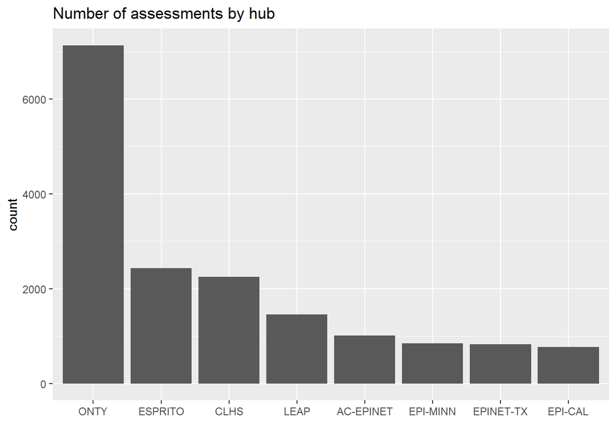

```r
ggplot(dat) +
  aes(x = fct_infreq(hub_c)) +
  geom_bar() +
  xlab("") +
  ggtitle("Number of assessments by hub")
```

Patients per hub.

```r
dat %>%
  select(hub_c, NDA_ID) %>%
  distinct() %>%
  group_by(hub_c) %>%
  summarise(number_of_people = n()) %>%
  arrange(desc(number_of_people))
```

```
## # A tibble: 8 x 2
##   hub_c     number_of_people
##   <fct>                <int>
## 1 ONTY                  1253
## 2 CLHS                   824
## 3 ESPRITO                775
## 4 LEAP                   766
## 5 AC-EPINET              462
## 6 EPI-CAL                402
## 7 EPINET-TX              398
## 8 EPI-MINN               286
```

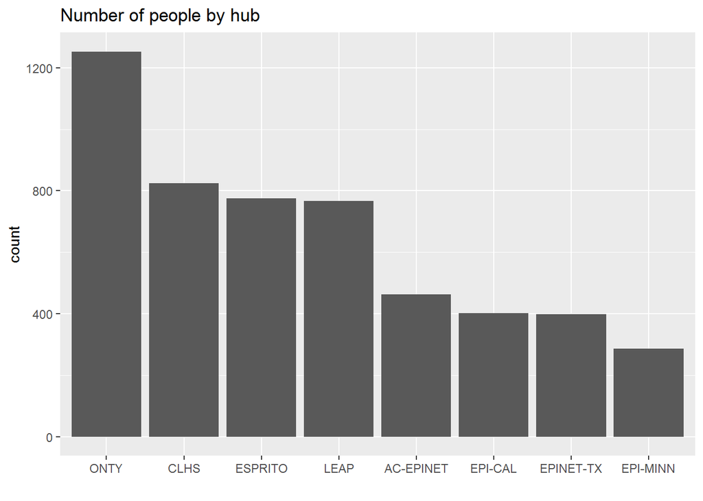

```r
dat %>%
  select(hub_c, NDA_ID) %>%
  distinct() %>%
  ggplot() +
  aes(x = fct_infreq(hub_c)) +
  geom_bar() + xlab("") +
  ggtitle("Number of people by hub")
```

Sites/clinics per hub.

```r
dat %>%
  select(hub_c, Site_ID) %>%
  distinct() %>%
  group_by(hub_c) %>%
  summarise(number_of_sites = n()) %>%
  arrange(desc(number_of_sites))
```

```
## # A tibble: 8 x 2
##   hub_c     number_of_sites
##   <fct>               <int>
## 1 ONTY                   26
## 2 CLHS                   23
## 3 EPI-CAL                18
## 4 EPINET-TX              16
## 5 ESPRITO                13
## 6 LEAP                   13
## 7 EPI-MINN                6
## 8 AC-EPINET               5
```

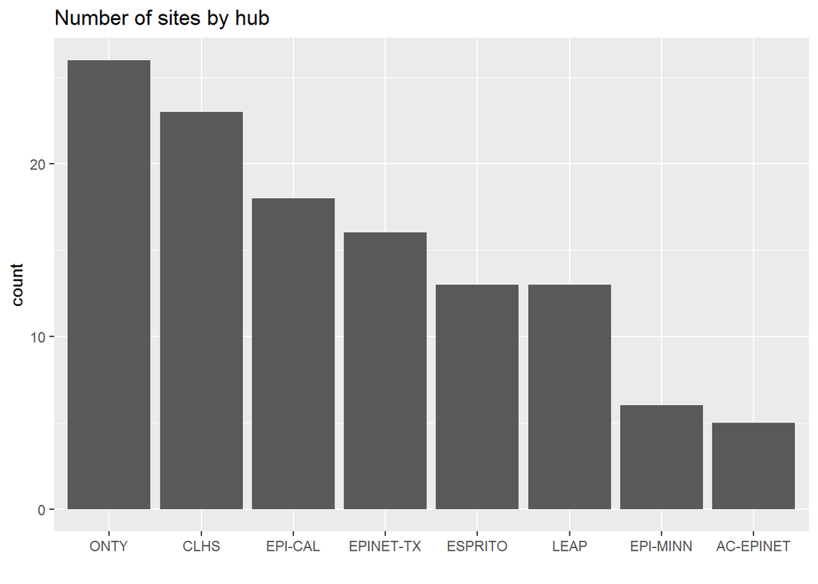

```r
dat %>%
  select(hub_c, Site_ID) %>%
  distinct() %>%
  ggplot() +
  aes(x = fct_infreq(hub_c)) +
  geom_bar() + xlab("") +
  ggtitle("Number of sites by hub")
```

### Discharge descriptives

Number of discharges per hub.

```r
table(dat$disch_visit, dat$hub_c)
```

```
##
##         AC-EPINET CLHS EPI-CAL EPI-MINN EPINET-TX ESPRITO LEAP ONTY
##   FALSE       891 1853     725      759       720    1959 1403 6594
##   TRUE        124  394      43       86       105     472   53  541
```

```r
prop.table(table(dat$disch_visit, dat$hub_c), margin = 2)
```

```
##
##          AC-EPINET       CLHS    EPI-CAL   EPI-MINN  EPINET-TX    ESPRITO
##   FALSE 0.87783251 0.82465510 0.94401042 0.89822485 0.87272727 0.80584122
##   TRUE  0.12216749 0.17534490 0.05598958 0.10177515 0.12727273 0.19415878
##
##               LEAP       ONTY
##   FALSE 0.96359890 0.92417659
##   TRUE  0.03640110 0.07582341
```

```r
nrow(dc_vis)
```

```
## [1] 1787
```

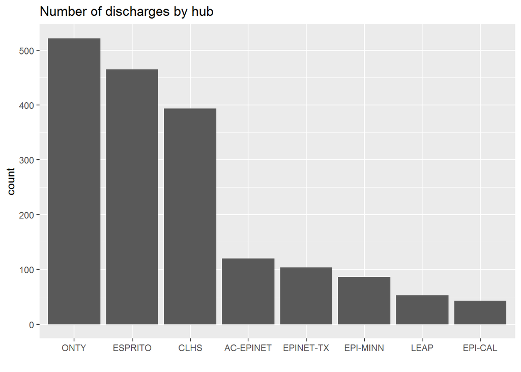

```r
ggplot(dc_vis) +
  aes(x=fct_infreq(hub_c)) +
  geom_bar() +
  xlab("") +
  ggtitle("Number of discharges by hub")
```

```r
dat %>%
  group_by(NDA_ID) %>%
  summarize(hub = unique(hub_c),
            disch = any(disch_visit)) %>%
  ungroup() %>% group_by(hub) %>%
  summarise(disch_rate = round(mean(disch) * 100,1)) %>%
  arrange(desc(disch_rate))
```

```
## # A tibble: 8 x 2
##   hub       disch_rate
##   <fct>          <dbl>
## 1 ESPRITO         60
## 2 CLHS            47.8
## 3 ONTY            41.7
## 4 EPI-MINN        30.1
## 5 EPINET-TX       26.1
## 6 AC-EPINET       26
## 7 EPI-CAL         10.7
## 8 LEAP             6.9
```

Type of discharge.

```r
# unrecoded counts
summary(factor(dc_vis$Reason_Discharge))
```

```
##    1    2    3    4    5    6    7    8    9   10   11   12   13   14   15 NA's
##  427  395   85   36   11    6    9  144   16  153    3    8  278  163   10   43
```

```r
round(prop.table(summary(factor(dc_vis$Reason_Discharge))), 3) * 100
```

```
##    1    2    3    4    5    6    7    8    9   10   11   12   13   14   15 NA's
## 23.9 22.1  4.8  2.0  0.6  0.3  0.5  8.1  0.9  8.6  0.2  0.4 15.6  9.1  0.6  2.4
```

```r
#recoded counts
summary(dc_vis$discharge_c)
```

```
##   unilateral_termination                completed               ineligible
##                      427                      431                       85
## pursuing_pos_opportunity             incarcerated     transferred_or_moved
##                       11                       31                      297
##                    death             lost_contact                    other
##                       21                      278                      163
##                     NA's
##                       43
```

```r
#rates
round(prop.table(summary(dc_vis$discharge_c)) * 100, 1)
```

```
##   unilateral_termination                completed               ineligible
##                     23.9                     24.1                      4.8
## pursuing_pos_opportunity             incarcerated     transferred_or_moved
##                      0.6                      1.7                     16.6
##                    death             lost_contact                    other
##                      1.2                     15.6                      9.1
##                     NA's
##                      2.4
```

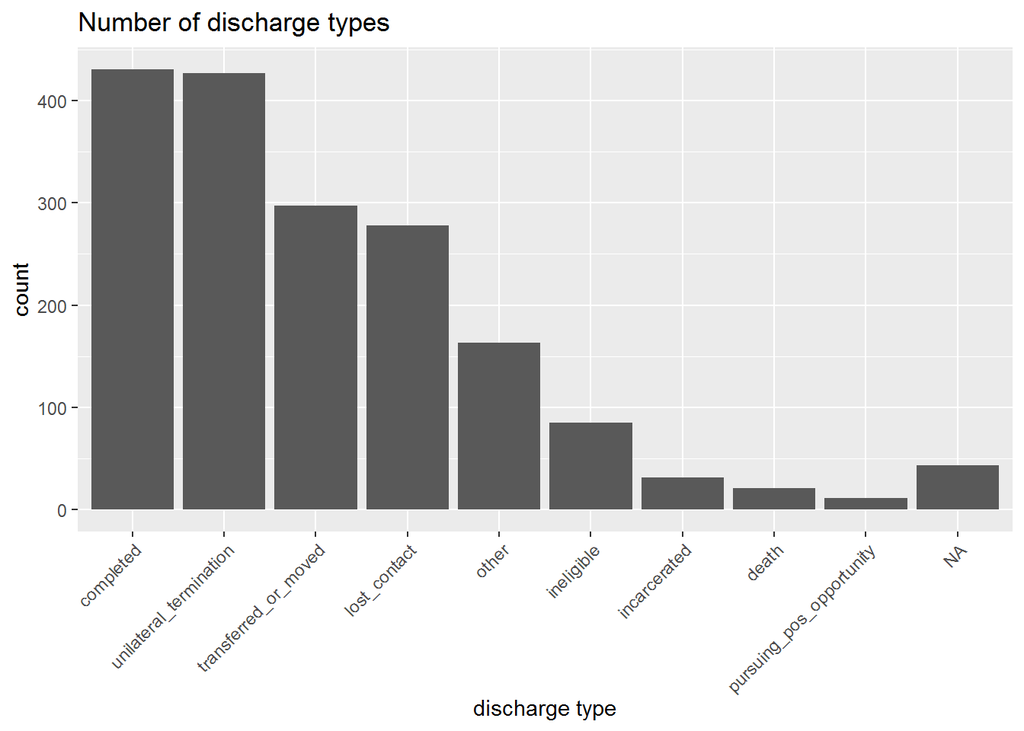

```r
ggplot(dc_vis) +
  aes(x = fct_infreq(discharge_c)) +
  geom_bar() +
  xlab("discharge type") +
  ggtitle("Number of discharge types") +
  theme(axis.text.x = element_text(angle=45, vjust = 1, hjust=1))
```

Discharge types by hub

```r
# counts
dc_vis %>%
  group_by(hub_c) %>%
  summarize(unilateral_termination = sum(discharge_c == "unilateral_termination", na.rm=T),
            completed = sum(discharge_c == "completed", na.rm=T),
            ineligible = sum(discharge_c == "ineligible", na.rm=T),
            transferred_or_moved = sum(discharge_c == "transferred_or_moved", na.rm=T),
            death = sum(discharge_c == "death", na.rm=T),
            lost_contact = sum(discharge_c == "lost_contact", na.rm=T),
            other = sum(discharge_c == "other", na.rm=T)
  )
```

```
## # A tibble: 8 x 8
##   hub_c   unilateral_termination completed ineligible transferred_or_moved death
##   <fct>                    <int>     <int>      <int>                <int> <int>
## 1 AC-EPI~                     27         6          5                   28     2
## 2 CLHS                        67        67         54                   44     0
## 3 EPI-CAL                      8        17          5                    4     0
## 4 EPI-MI~                     10        44          4                    7     0
## 5 EPINET~                     43         6          1                   26     4
## 6 ESPRITO                     85       168         10                   89     5
## 7 LEAP                        18        11          6                    4     0
## 8 ONTY                       169       112          0                   95    10
## # i 2 more variables: lost_contact <int>, other <int>
```

```r
# rates
dc_vis %>%
  group_by(hub_c) %>%
  summarize(unilateral_termination = mean(discharge_c == "unilateral_termination", na.rm=T),
            completed = mean(discharge_c == "completed", na.rm=T),
            ineligible = mean(discharge_c == "ineligible", na.rm=T),
            transferred_or_moved = mean(discharge_c == "transferred_or_moved", na.rm=T),
            death = mean(discharge_c == "death", na.rm=T),
            lost_contact = mean(discharge_c == "lost_contact", na.rm=T),
            other = mean(discharge_c == "other", na.rm=T)
  )
```

```
## # A tibble: 8 x 8
##   hub_c  unilateral_termination completed ineligible transferred_or_moved  death
##   <fct>                   <dbl>     <dbl>      <dbl>                <dbl>  <dbl>
## 1 AC-EP~                  0.225    0.05      0.0417                0.233  0.0167
## 2 CLHS                    0.170    0.170     0.137                 0.112  0
## 3 EPI-C~                  0.186    0.395     0.116                 0.0930 0
## 4 EPI-M~                  0.128    0.564     0.0513                0.0897 0
## 5 EPINE~                  0.413    0.0577    0.00962               0.25   0.0385
## 6 ESPRI~                  0.195    0.386     0.0230                0.205  0.0115
## 7 LEAP                    0.36     0.22      0.12                  0.08   0
## 8 ONTY                    0.324    0.215     0                     0.182  0.0192
## # i 2 more variables: lost_contact <dbl>, other <dbl>
```

# 3 Identifying predictors of discharge type

Let’s do some exploratory plotting to understand discharge types.

## 3.1 Race

Here’s the race breakdown for the cohort that discharged.

```r
table(dc_vis$simple_race)
```

```
##
##       White    Hispanic       Black Multiracial       Other    AsianAPI
##         525         279         586          80         225          92
```

```r
table(dc_vis$race_c)
```

```
##
##                           AI                          API
##                           11                            5
##                        Asian                        Black
##                           87                          586
##                     Hispanic                  Multiracial
##                          279                           80
##                        Other unknown or prefer not to say
##                            3                          211
##                        White
##                          525
```

```r
proportions <- prop.table(with(dc_vis, table(simple_race, discharge_c)), margin = 1)
round(proportions * 100, 1)
```

```
##              discharge_c
## simple_race   unilateral_termination completed ineligible
##   White                         25.1      29.4        5.3
##   Hispanic                      30.0      28.9        3.3
##   Black                         24.3      18.9        3.1
##   Multiracial                   26.6      30.4        7.6
##   Other                         17.3      23.6        8.6
##   AsianAPI                      21.7      20.7        6.5
##              discharge_c
## simple_race   pursuing_pos_opportunity incarcerated transferred_or_moved death
##   White                            1.2          2.0                 18.2   1.2
##   Hispanic                         0.4          0.7                 16.3   1.1
##   Black                            0.5          2.1                 17.0   1.4
##   Multiracial                      0.0          2.5                 15.2   1.3
##   Other                            0.0          0.5                 11.8   1.4
##   AsianAPI                         1.1          4.3                 27.2   0.0
##              discharge_c
## simple_race   lost_contact other
##   White                8.5   9.1
##   Hispanic            10.0   9.3
##   Black               26.9   5.9
##   Multiracial         12.7   3.8
##   Other               16.4  20.5
##   AsianAPI             7.6  10.9
```

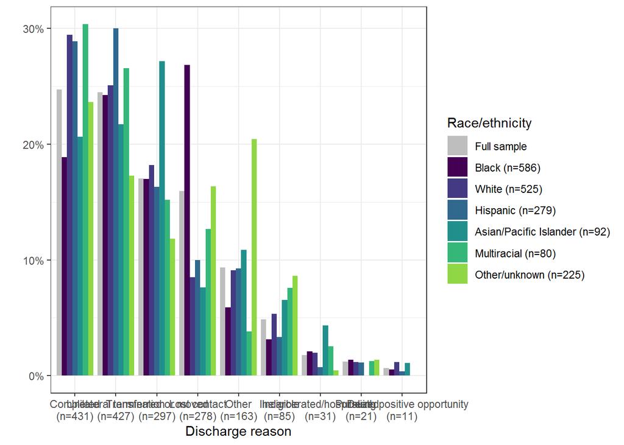

```r
proportions <- data.frame(proportions)
full_sample <- as.data.frame(prop.table(table(dc_vis$discharge_c)))
names(full_sample) <- c("discharge_c", "Freq")
full_sample$simple_race <- "Full sample"
proportions <- bind_rows(proportions, full_sample)
proportions <- mutate(
  proportions,
  simple_race = factor(simple_race,
                       levels = c("Full sample","Black", "White", "Hispanic", "AsianAPI", "Multiracial", "Other"),
                       labels=c("Full sample","Black (n=586)", "White (n=525)",  "Hispanic (n=279)", "Asian/Pacific Islander (n=92)", "Multiracial (n=80)", "Other/unknown (n=225)")),
  discharge_c = factor(discharge_c,
                       levels = c("completed",
                                  "unilateral_termination",
                                  "transferred_or_moved",
                                  "lost_contact",
                                  "other",
                                  "ineligible",
                                  "incarcerated",
                                  "death",
                                  "pursuing_pos_opportunity"),
                       labels=c("Completed\n(n=431)",
                                "Unilateral termination\n(n=427)",
                                "Transferred or moved\n(n=297)",
                                "Lost contact\n(n=278)",
                                "Other\n(n=163)",
                                "Ineligible\n(n=85)",
                                "Incarcerated/hospitalized\n(n=31)",
                                "Death\n(n=21)",
                                "Pursuing positive opportunity\n(n=11)"))
)

fill_colors <- c("grey", scales::viridis_pal()(7))
# fill_colors <- scales::viridis_pal(option="magma")(8)

proportions %>%
  ggplot() +
  aes(x = discharge_c, y = Freq, fill = simple_race) +
  geom_bar(stat="identity", position="dodge") +
  scale_y_continuous(labels=scales::percent) +
  ylab("") + xlab("Discharge reason") +
  guides(fill=guide_legend(title="Race/ethnicity")) +
  scale_fill_manual(values=fill_colors) +
  theme_bw()
```

We can compare expected rates by race with actual rates by race. Black people are much more likely to be lost to follow-up.

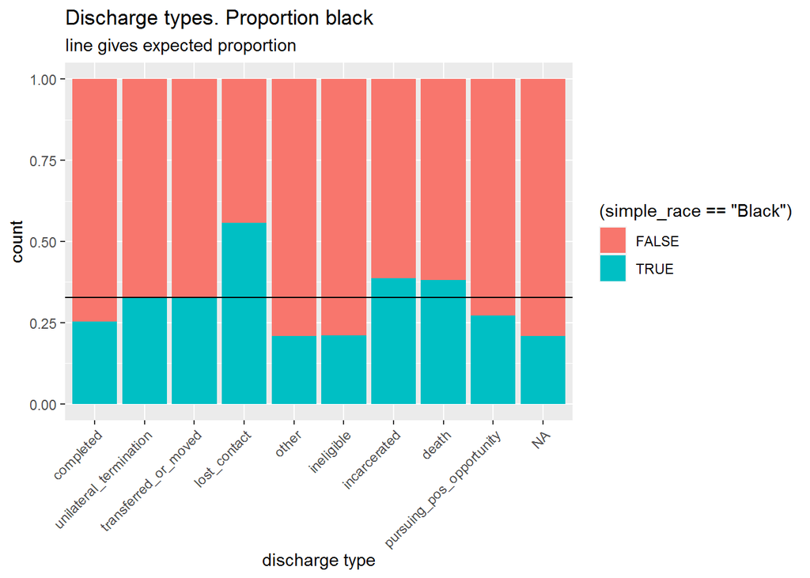

```r
rate_black <- mean(dc_vis$simple_race == "Black")
ggplot(dc_vis) +
  aes(x = fct_infreq(discharge_c), fill=(simple_race == "Black")) +
  geom_bar(position="fill") +
  geom_hline(yintercept = rate_black) +
  xlab("discharge type") +
  ggtitle("Discharge types. Proportion black", subtitle="line gives expected proportion") +
  theme(axis.text.x = element_text(angle=45, vjust = 1, hjust=1))
```

#### Race and gender?

Visually, it kind of looked to me as though there was a two-way interaction between race and gender, with black males particularly unlikely to complete the program.

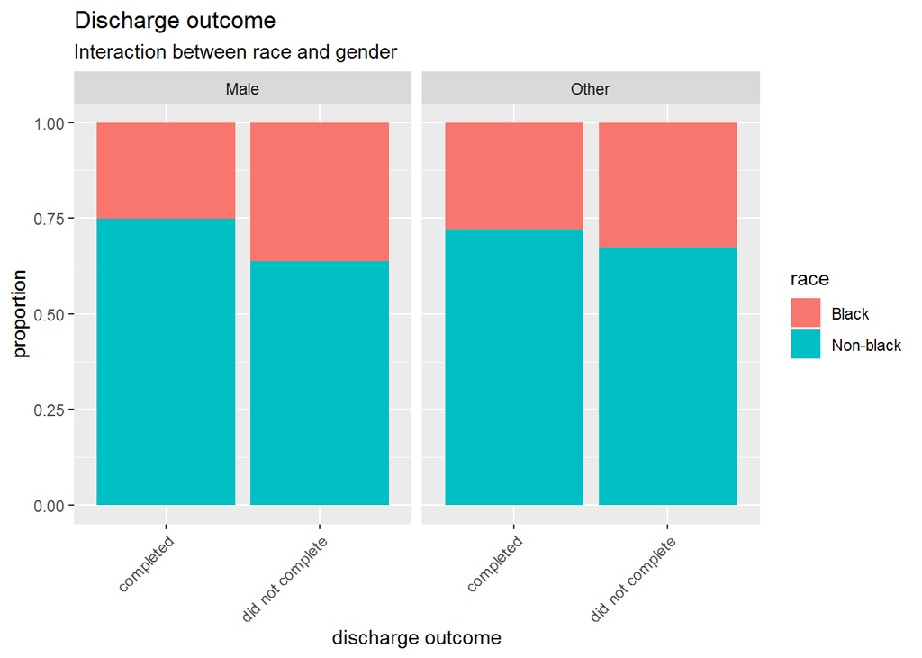

```r
dc_vis %>%
  mutate(
    race = ifelse(simple_race=="Black", "Black", "Non-black"),
    gender = ifelse(male_c, "Male", "Other"),
    outcome = ifelse(completed, "completed", "did not complete")
  ) %>%
  ggplot() +
  aes(x = outcome, fill=race) +
  geom_bar(position="fill") +
  xlab("discharge outcome") +
  ylab("proportion") +
  ggtitle("Discharge outcome", subtitle="Interaction between race and gender") +
  theme(axis.text.x = element_text(angle=45, vjust = 1, hjust=1)) +
  facet_wrap(~gender)
```

However, the effect doesn’t appear to be robust.

```r
summary(glm(completed ~ (simple_race == "Black") + male_c +
      (simple_race == "Black"):male_c,
    family="binomial",
    data = dc_vis))
```

```
##
## Call:
## glm(formula = completed ~ (simple_race == "Black") + male_c +
##     (simple_race == "Black"):male_c, family = "binomial", data = dc_vis)
##
## Coefficients:
##                                        Estimate Std. Error z value
## (Intercept)                           -0.997223   0.106364  -9.376
## simple_race == "Black"TRUE            -0.221534   0.197178  -1.124
## male_cTRUE                             0.002331   0.134391   0.017
## simple_race == "Black"TRUE:male_cTRUE -0.307069   0.252067  -1.218
##                                                  Pr(>|z|)
## (Intercept)                           <0.0000000000000002 ***
## simple_race == "Black"TRUE                          0.261
## male_cTRUE                                          0.986
## simple_race == "Black"TRUE:male_cTRUE               0.223
## ---
## Signif. codes:  0 '***' 0.001 '**' 0.01 '*' 0.05 '.' 0.1 ' ' 1
##
## (Dispersion parameter for binomial family taken to be 1)
##
##     Null deviance: 1992.6  on 1786  degrees of freedom
## Residual deviance: 1978.8  on 1783  degrees of freedom
## AIC: 1986.8
##
## Number of Fisher Scoring iterations: 4
```

## 3.2 Age

First some descriptives for the discharged sample.

```r
mean(dc_vis$Age_Entry_Years, na.rm=T)
```

```
## [1] 21.87464
```

```r
sd(dc_vis$Age_Entry_Years, na.rm=T)
```

```
## [1] 4.198462
```

```r
sum(is.na(dc_vis$Age_Entry_Years))
```

```
## [1] 178
```

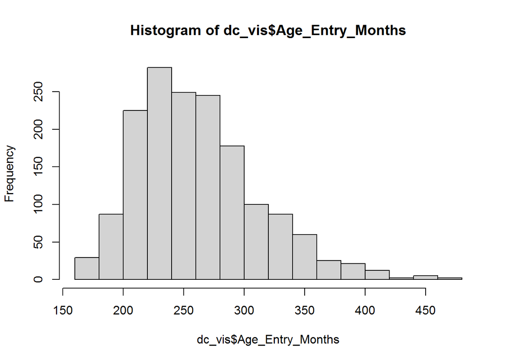

```r
hist(dc_vis$Age_Entry_Months)
```

Age is related to discharge

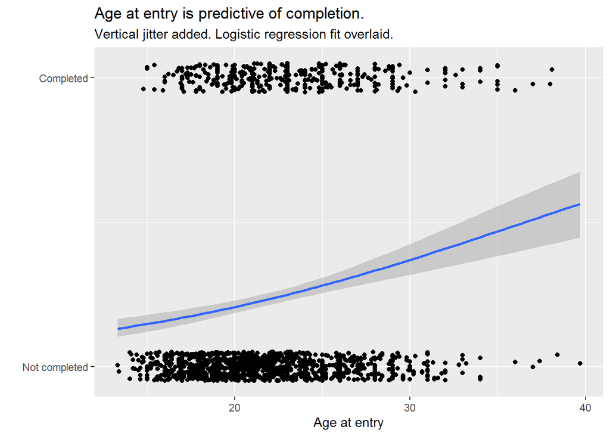

```r
dc_vis %>%
  ggplot() +
  aes(x = Age_Entry_Years, y = as.numeric(completed)) +
  geom_jitter(width = 0, height = 0.05) +
  geom_smooth(method="glm", method.args=list(family="binomial")) +
  ggtitle("Age at entry is predictive of completion.",
          subtitle = "Vertical jitter added. Logistic regression fit overlaid.") +
  xlab("Age at entry") +
  ylab("") +
  scale_y_continuous(breaks = 0:1, labels=c("Not completed", "Completed"))
```

## 3.3 Time in program

Duration in program is a wonderful predictor of program completion, but in some ways that’s tautological given that patients are approximately defined as completing the program if they last two years.

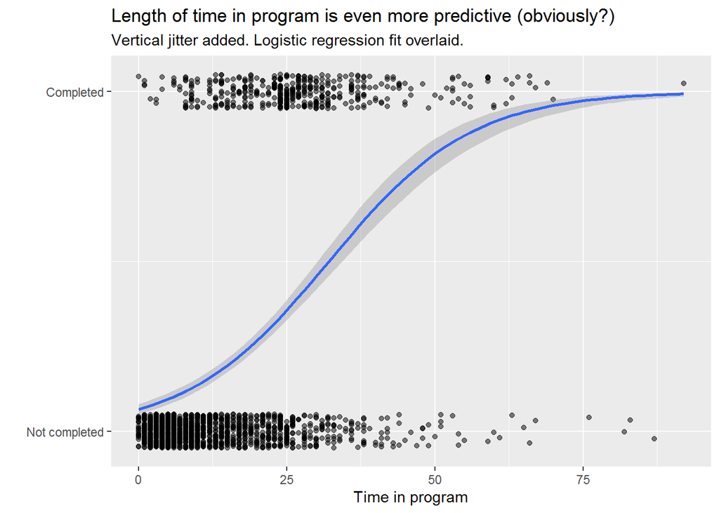

```r
# duration in program versus program completion
dc_vis %>%
  ggplot() +
  aes(x = CSC_Duration_Totalmos, y = as.numeric(completed)) +
  geom_jitter(width = 0, height = 0.05, alpha=0.5) +
  geom_smooth(method="glm", method.args=list(family="binomial")) +
  ggtitle("Length of time in program is even more predictive (obviously?)",
          subtitle = "Vertical jitter added. Logistic regression fit overlaid.") +
  xlab("Time in program") +
  ylab("") +
  scale_y_continuous(breaks = 0:1, labels=c("Not completed", "Completed"))
```

Each year in the program is associated with approximately 3x greater odds of program completion.

```r
fit <- glm( completed ~ CSC_Duration_Totalmos,
            data = dc_vis, family=binomial)
exp(coef(fit)[2] * 12) # coefficient for months, times 12, exponentiated
```

```
## CSC_Duration_Totalmos
##              2.718064
```

```r
# confint
exp(confint(fit)[2,] * 12)
```

```
##    2.5 %   97.5 %
## 2.412285 3.077916
```

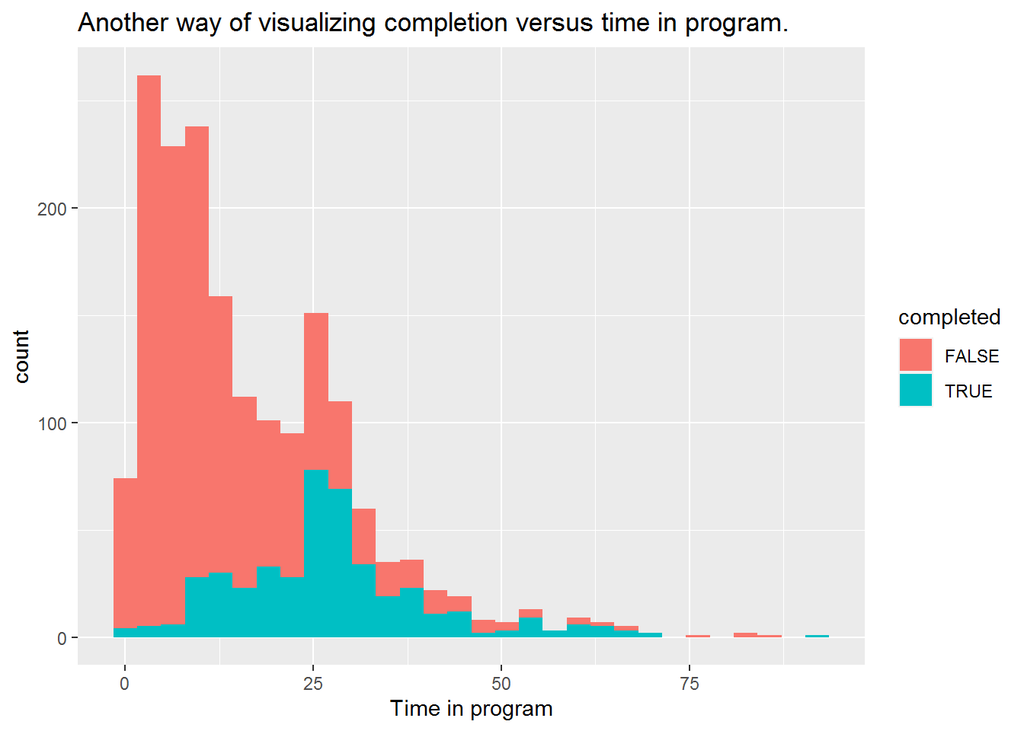

```r
dc_vis %>%
  ggplot() +
  aes(x = CSC_Duration_Totalmos, fill = completed) +
  geom_histogram() +
  ggtitle("Another way of visualizing completion versus time in program.") +
  xlab("Time in program")
```

Age and time in program predict completion even after controlling for each other.

```r
fit <- glm( completed ~ Age_Entry_Years + CSC_Duration_Totalmos,
            data = dc_vis, family=binomial)
summary(fit)
```

```
##
## Call:
## glm(formula = completed ~ Age_Entry_Years + CSC_Duration_Totalmos,
##     family = binomial, data = dc_vis)
##
## Coefficients:
##                        Estimate Std. Error z value             Pr(>|z|)
## (Intercept)           -4.104642   0.372725 -11.013 < 0.0000000000000002 ***
## Age_Entry_Years        0.055244   0.015718   3.515              0.00044 ***
## CSC_Duration_Totalmos  0.091602   0.005926  15.456 < 0.0000000000000002 ***
## ---
## Signif. codes:  0 '***' 0.001 '**' 0.01 '*' 0.05 '.' 0.1 ' ' 1
##
## (Dispersion parameter for binomial family taken to be 1)
##
##     Null deviance: 1763.7  on 1608  degrees of freedom
## Residual deviance: 1400.1  on 1606  degrees of freedom
##   (178 observations deleted due to missingness)
## AIC: 1406.1
##
## Number of Fisher Scoring iterations: 5
```

## 3.4 Symptoms

We plot the observed trajectories in self-reported symptoms and discharge type. Keep in mind that the curves plotted over these graphs do *not* take into account the issue of differing numbers of observations per person.

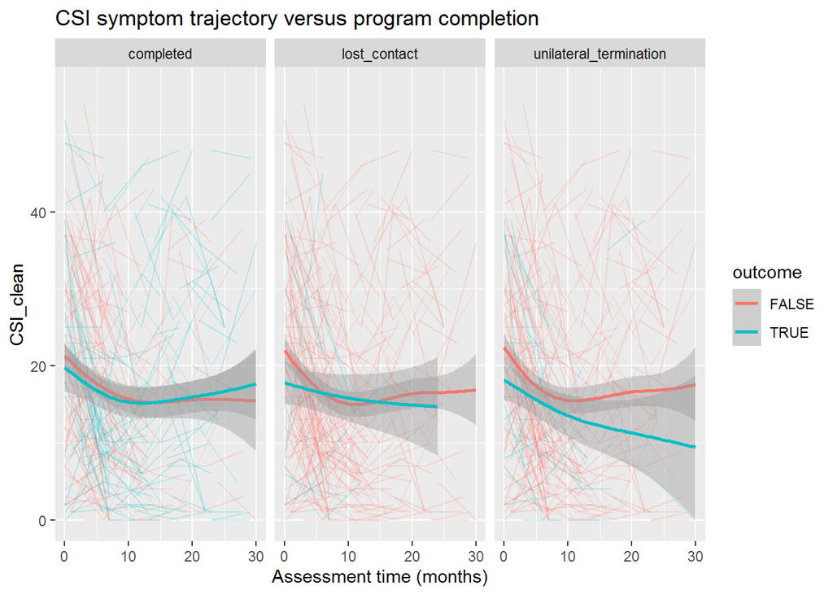

```r
dc %>%
  pivot_longer(cols = c(completed,unilateral_termination,lost_contact),
               names_to = "discharge_type", values_to = "outcome") %>%
  ggplot() +
  aes(x = CSC_Duration_Totalmos, y = CSI_clean, group = NDA_ID, color = outcome) +
  geom_line(alpha=0.2) +
  geom_smooth(aes(x = CSC_Duration_Totalmos, y = CSI_clean, group = outcome)) +
  ggtitle("CSI symptom trajectory versus program completion") +
  xlab("Assessment time (months)") +
  xlim(c(0,30)) +
  facet_wrap(~discharge_type)
```

These plots suggest there’s not much effect of self-reported symptom severity, but perhaps something is going on with unilateral termination. However, the above graphs don’t account for the multilevel structure of the data, so let’s use a formal model to verify.

```r
csi_fit <- stan_glmer(unilateral_termination ~
                        # interaction between (scaled) CSI scores and time.
                      (scale(CSI_clean) + scale(CSC_Duration_Totalmos))^2 +
                      # account for clustering
                      (1|hub_c) + (1|Site_ID) + (1|NDA_ID),
                 data = dc,
                 adapt_delta=0.99,
                 family=binomial,
                 iter = 3000,
                 cores=4)
```

Duration in the program is a strong predictor of `unilateral_termination`, but CSI scores and changes in CSI scores over time aren’t significantly predictive.

```r
print(csi_fit, digits=3)
```

```
## stan_glmer
##  family:       binomial [logit]
##  formula:      unilateral_termination ~ (scale(CSI_clean) + scale(CSC_Duration_Totalmos))^2 +
##     (1 | hub_c) + (1 | Site_ID) + (1 | NDA_ID)
##  observations: 1103
## ------
##                                               Median MAD_SD
## (Intercept)                                   -6.808  1.413
## scale(CSI_clean)                              -0.394  0.460
## scale(CSC_Duration_Totalmos)                  -2.013  0.546
## scale(CSI_clean):scale(CSC_Duration_Totalmos)  0.797  0.482
##
## Error terms:
##  Groups  Name        Std.Dev.
##  NDA_ID  (Intercept) 8.638
##  Site_ID (Intercept) 2.105
##  hub_c   (Intercept) 2.858
## Num. levels: NDA_ID 726, Site_ID 63, hub_c 7
##
## ------
## * For help interpreting the printed output see ?print.stanreg
## * For info on the priors used see ?prior_summary.stanreg
```

Now do the same with negative symptoms.

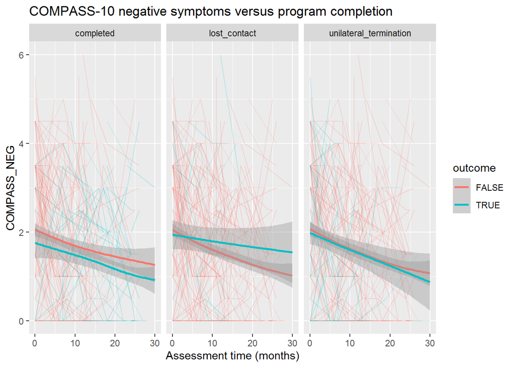

```r
dc %>%
  pivot_longer(cols = c(completed,unilateral_termination,lost_contact),
               names_to = "discharge_type", values_to = "outcome") %>%
  ggplot() +
  aes(x = CSC_Duration_Totalmos, y = COMPASS_NEG, group = NDA_ID, color = outcome) +
  geom_line(alpha=0.2) +
  geom_smooth(aes(x = CSC_Duration_Totalmos, y = COMPASS_NEG, group = outcome)) +
  ggtitle("COMPASS-10 negative symptoms versus program completion") +
  xlab("Assessment time (months)") +
  xlim(c(0,30)) +
  facet_wrap(~discharge_type)
```

Maybe something is happening for program completion (with higher negative symptoms predicting less likelihood of completion) and lost contact (with greater decreases in negative symptoms predicting retention of contact). We’ll check both.

```r
fit_neg_comp <- stan_glmer(completed ~
                   (scale(COMPASS_NEG) + scale(CSC_Duration_Totalmos))^2 +
                   # account for clustering
                   (1|hub_c) + (1|Site_ID) + (1|NDA_ID),
                 data = dc,
                 family=binomial,
                 cores=4)

# same model, but predicting lost_contact
fit_neg_lost <- update(fit_neg_comp, lost_contact ~ .)
```

There was no relationship between negative symptoms and lost contact (as parameterized by this model).

```r
print(fit_neg_lost, digits=3)
```

```
## stan_glmer
##  family:       binomial [logit]
##  formula:      lost_contact ~ scale(COMPASS_NEG) + scale(CSC_Duration_Totalmos) +
##     (1 | hub_c) + (1 | Site_ID) + (1 | NDA_ID) + scale(COMPASS_NEG):scale(CSC_Duration_Totalmos)
##  observations: 1184
## ------
##                                                 Median MAD_SD
## (Intercept)                                     -8.617  1.233
## scale(COMPASS_NEG)                               0.047  0.387
## scale(CSC_Duration_Totalmos)                    -2.080  0.546
## scale(COMPASS_NEG):scale(CSC_Duration_Totalmos)  0.047  0.450
##
## Error terms:
##  Groups  Name        Std.Dev.
##  NDA_ID  (Intercept) 6.479
##  Site_ID (Intercept) 3.677
##  hub_c   (Intercept) 1.194
## Num. levels: NDA_ID 750, Site_ID 83, hub_c 8
##
## ------
## * For help interpreting the printed output see ?print.stanreg
## * For info on the priors used see ?prior_summary.stanreg
```

But people who completed had statistically significantly lower negative symptoms than people who did not complete.

```r
print(fit_neg_comp, digits=3)
```

```
## stan_glmer
##  family:       binomial [logit]
##  formula:      completed ~ (scale(COMPASS_NEG) + scale(CSC_Duration_Totalmos))^2 +
##     (1 | hub_c) + (1 | Site_ID) + (1 | NDA_ID)
##  observations: 1184
## ------
##                                                 Median MAD_SD
## (Intercept)                                     -4.703  1.563
## scale(COMPASS_NEG)                              -1.000  0.460
## scale(CSC_Duration_Totalmos)                     4.087  0.664
## scale(COMPASS_NEG):scale(CSC_Duration_Totalmos) -0.117  0.454
##
## Error terms:
##  Groups  Name        Std.Dev.
##  NDA_ID  (Intercept) 9.234
##  Site_ID (Intercept) 4.679
##  hub_c   (Intercept) 4.406
## Num. levels: NDA_ID 750, Site_ID 83, hub_c 8
##
## ------
## * For help interpreting the printed output see ?print.stanreg
## * For info on the priors used see ?prior_summary.stanreg
```

```r
posterior_interval(fit_neg_comp, pars="scale(COMPASS_NEG)", prob=0.95)
```

```
##                         2.5%      97.5%
## scale(COMPASS_NEG) -1.940931 -0.1113606
```

Given this finding, we’ll want to include negative symptom scores in later models. To do this, we’ll need to get an average negative symptom score for each participant and stack it onto the discharge dataframe. We do this with a model because it allows us to get a better estimate of the average given the multilevel structure of the data, and because it allows us to impute missing data for people without COMPASS data.

```r
neg_average_model <- stan_lmer(
  COMPASS_NEG ~
    # this is an intercept-only model.
    # we get the expected average for each person in each site in each hub
    (1|NDA_ID) +
    (1|Site_ID) +
    (1|hub_c),
  data=dat,
  cores=4,
  iter=2000
  )
```

We use the above model to get estimated negative symptom scores for each person.

```r
# first whole dataset
neg_est <- posterior_epred(neg_average_model,
                             newdata=dat %>% select(NDA_ID,Site_ID,hub_c))
dat$NEG_avg <- apply(neg_est, 2, mean)
# then discharge visit only
neg_est <- posterior_epred(neg_average_model,
                             newdata=dc_vis %>% select(NDA_ID,Site_ID,hub_c))
dc_vis$NEG_avg <- apply(neg_est, 2, mean)
```

There doesn’t appear to be any relationship between positive symptom severity (or its trajectory) and discharge type, so we don’t examine this variable further.

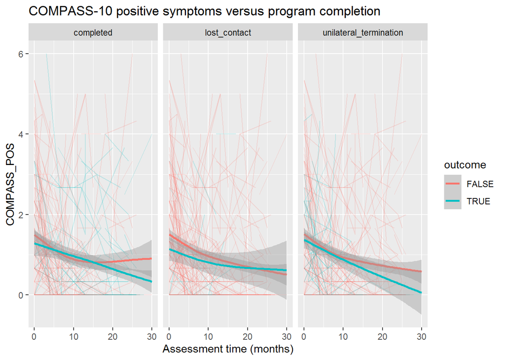

```r
dc %>%
  pivot_longer(cols = c(completed,unilateral_termination,lost_contact),
               names_to = "discharge_type", values_to = "outcome") %>%
  ggplot() +
  aes(x = CSC_Duration_Totalmos, y = COMPASS_POS, group = NDA_ID, color = outcome) +
  geom_line(alpha=0.2) +
  geom_smooth(aes(x = CSC_Duration_Totalmos, y = COMPASS_POS, group = outcome)) +
  ggtitle("COMPASS-10 positive symptoms versus program completion") +
  xlab("Assessment time (months)") +
  xlim(c(0,30)) +
  facet_wrap(~discharge_type)
```

## 3.5 NEET

NEET means not employed, in education, or in training. For this dataset I define NEET as not being employed, in school, or in an internship in the six months prior to the assessment timepoint.

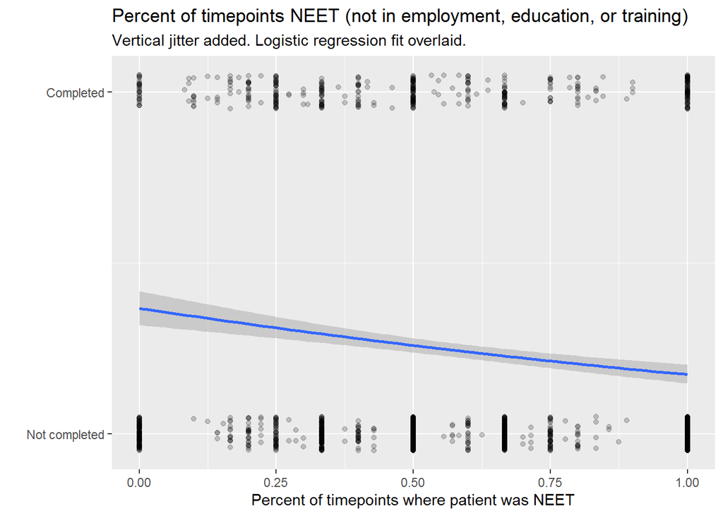

```r
dc_vis %>%
  ggplot() +
  aes(x = percent_NEET, y = as.numeric(completed)) +
  geom_jitter(width = 0, height = 0.05, alpha=0.2) +
  geom_smooth(method="glm", method.args=list(family="binomial")) +
  ggtitle("Percent of timepoints NEET (not in employment, education, or training)",
          subtitle = "Vertical jitter added. Logistic regression fit overlaid.") +
  xlab("Percent of timepoints where patient was NEET") +
  ylab("") +
  scale_y_continuous(breaks = 0:1, labels=c("Not completed", "Completed"))
```

## 3.6 Insurance status

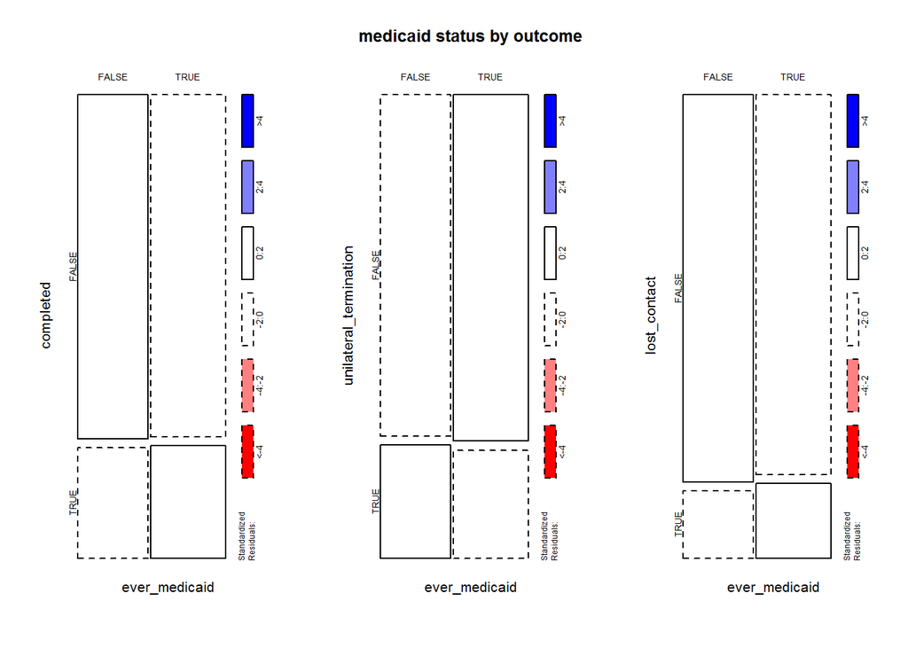

```r
## medicaid
par(mfrow= c(1,3))
with(dc_vis,
     mosaicplot(table(ever_medicaid, completed), shade=TRUE,
                main = ""))
with(dc_vis,
     mosaicplot(table(ever_medicaid, unilateral_termination), shade=TRUE,
                 main = "medicaid status by outcome"))
with(dc_vis,
     mosaicplot(table(ever_medicaid, lost_contact), shade=TRUE,
                 main = ""))
```

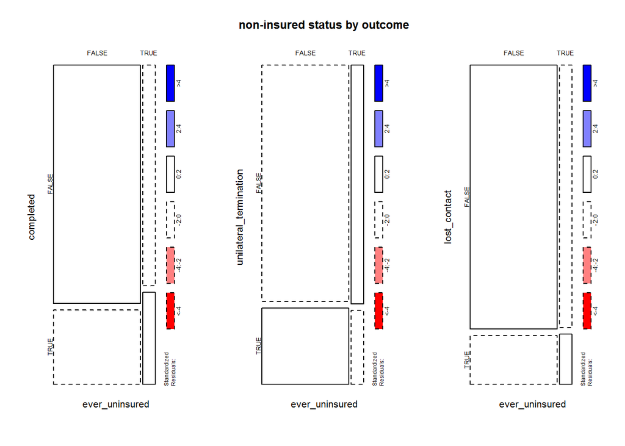

```r
## non-insured
with(dc_vis,
     mosaicplot(table(ever_uninsured, completed), shade=TRUE,
                main = ""))
with(dc_vis,
     mosaicplot(table(ever_uninsured, unilateral_termination), shade=TRUE,
                 main = "non-insured status by outcome"))
with(dc_vis,
     mosaicplot(table(ever_uninsured, lost_contact), shade=TRUE,
                 main = ""))
```

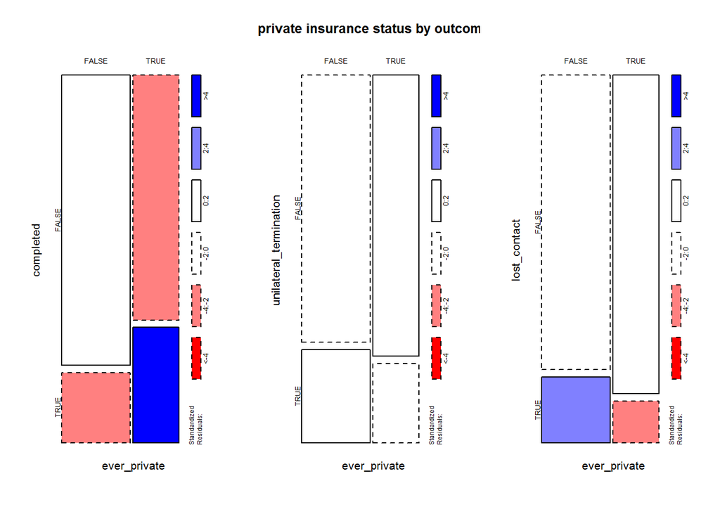

```r
## private
with(dc_vis,
     mosaicplot(table(ever_private, completed), shade=TRUE,
                main = ""))
with(dc_vis,
     mosaicplot(table(ever_private, unilateral_termination), shade=TRUE,
                 main = "private insurance status by outcome"))
with(dc_vis,
     mosaicplot(table(ever_private, lost_contact), shade=TRUE,
                 main = ""))
```

## 3.7 Recovery

Recovery (quantified by the QPR) *looks* like a decent predictor of lost contact, where CSC programs seem to be more likely to lose contact with people who have higher recovery ratings.

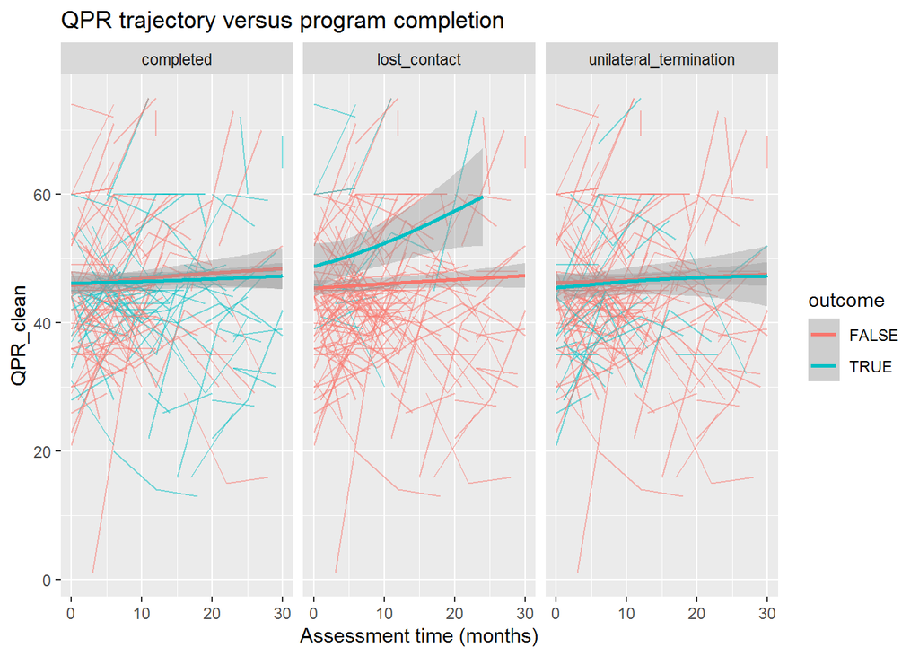

```r
dc %>%
  pivot_longer(cols = c(completed,unilateral_termination,lost_contact),
               names_to = "discharge_type", values_to = "outcome") %>%
  ggplot() +
  aes(x = CSC_Duration_Totalmos, y = QPR_clean, group = NDA_ID, color = outcome) +
  geom_line(alpha=0.5) +
  geom_smooth(aes(x = CSC_Duration_Totalmos, y = QPR_clean, group = outcome)) +
  ggtitle("QPR trajectory versus program completion") +
  xlab("Assessment time (months)") +
  xlim(0,30) +
  facet_wrap(~discharge_type)
```

We estimate this using QPR score as well as it’s interaction with time in order to model the effect of QPR scores and their trajectories.

```r
fit_QPR <- stan_glmer(lost_contact ~
                   (scale(QPR_clean) + scale(CSC_Duration_Totalmos))^2 +
                   # account for clustering
                   (1|hub_c) + (1|Site_ID) + (1|NDA_ID),
                 data = dc,
                 family=binomial,
                 adapt_delta = 0.99,
                 cores=4)
```

```r
fit_QPR
```

```
## stan_glmer
##  family:       binomial [logit]
##  formula:      lost_contact ~ (scale(QPR_clean) + scale(CSC_Duration_Totalmos))^2 +
##     (1 | hub_c) + (1 | Site_ID) + (1 | NDA_ID)
##  observations: 1008
## ------
##                                               Median MAD_SD
## (Intercept)                                   -8.2    1.3
## scale(QPR_clean)                               1.0    0.5
## scale(CSC_Duration_Totalmos)                  -1.7    0.5
## scale(QPR_clean):scale(CSC_Duration_Totalmos)  0.5    0.4
##
## Error terms:
##  Groups  Name        Std.Dev.
##  NDA_ID  (Intercept) 5.6
##  Site_ID (Intercept) 1.6
##  hub_c   (Intercept) 1.7
## Num. levels: NDA_ID 666, Site_ID 64, hub_c 7
##
## ------
## * For help interpreting the printed output see ?print.stanreg
## * For info on the priors used see ?prior_summary.stanreg
```

```r
exp(posterior_interval(fit_QPR, pars="scale(QPR_clean)", probs = c(0.025, 0.975)))
```

```
##                        5%      95%
## scale(QPR_clean) 1.355336 6.057725
```

We’ll want to use QPR scores in later models. To do this, we’ll need to get an average QPR score for each participant and stack it onto the discharge dataframe.

```r
QPR_average_model <- stan_lmer(
  QPR_clean ~
    # this is an intercept-only model.
    # we get the expected average for each person in each site in each hub
    (1|NDA_ID) +
    (1|Site_ID) +
    (1|hub_c),
  data=dat,
  cores=4,
  iter=2000
  )
```

We use the above model to get estimated QPR scores for each person. This code is actually run as the markdown is created.

```r
# first whole dataset
qpr_est <- posterior_epred(QPR_average_model,
                             newdata=dat %>% select(NDA_ID,Site_ID,hub_c))
dat$QPR_avg <- apply(qpr_est, 2, mean)
# then discharge visit only
qpr_est <- posterior_epred(QPR_average_model,
                             newdata=dc_vis %>% select(NDA_ID,Site_ID,hub_c))
dc_vis$QPR_avg <- apply(qpr_est, 2, mean)
```

# 4 Modeling discharge outcome

## 4.1 Program completion

```r
fit_comp <-
  stan_glmer(
    completed ~
      scale(Age_Entry_Years) +
      percent_NEET +
      male_c +
      ever_private +
      scale(QPR_avg) +
      scale(NEG_avg) +
      (1|Site_ID)  +
      (1|hub_c) +
      # varying intercept for race
      (1|simple_race) +
      # check if different hubs have different race effects?
      (1|Site_ID:simple_race) +
      (1|hub_c:simple_race),
    data = dc_vis,
    cores=4,
    family=binomial
  )
```

Interrogate the model.

```r
# overall model fit
print(fit_comp, digits=3)
```

```
## stan_glmer
##  family:       binomial [logit]
##  formula:      completed ~ scale(Age_Entry_Years) + percent_NEET + male_c +
##     ever_private + scale(QPR_avg) + scale(NEG_avg) + (1 | Site_ID) +
##     (1 | hub_c) + (1 | simple_race) + (1 | Site_ID:simple_race) +
##     (1 | hub_c:simple_race)
##  observations: 1609
## ------
##                        Median MAD_SD
## (Intercept)            -1.160  0.465
## scale(Age_Entry_Years)  0.287  0.073
## percent_NEET           -0.908  0.283
## male_cTRUE             -0.201  0.145
## ever_privateTRUE        0.596  0.148
## scale(QPR_avg)          0.193  0.162
## scale(NEG_avg)         -0.406  0.109
##
## Error terms:
##  Groups              Name        Std.Dev.
##  Site_ID:simple_race (Intercept) 0.6657
##  Site_ID             (Intercept) 0.8147
##  hub_c:simple_race   (Intercept) 0.2364
##  hub_c               (Intercept) 1.1438
##  simple_race         (Intercept) 0.2286
## Num. levels: Site_ID:simple_race 310, Site_ID 86, hub_c:simple_race 41, hub_c 7, simple_race 6
##
## ------
## * For help interpreting the printed output see ?print.stanreg
## * For info on the priors used see ?prior_summary.stanreg
```

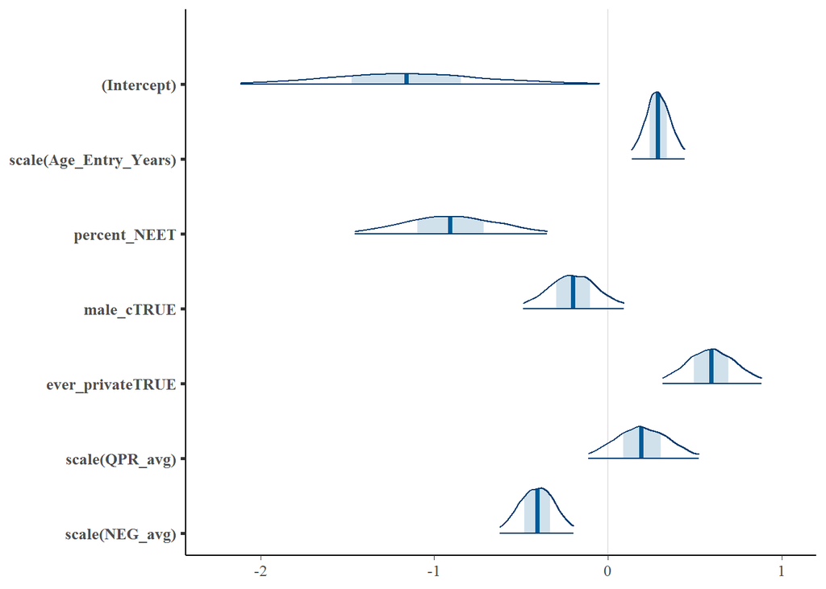

```r
# fixed effects
plot(fit_comp, pars = names(fixef(fit_comp)), prob_outer=0.95, plotfun="areas")
```

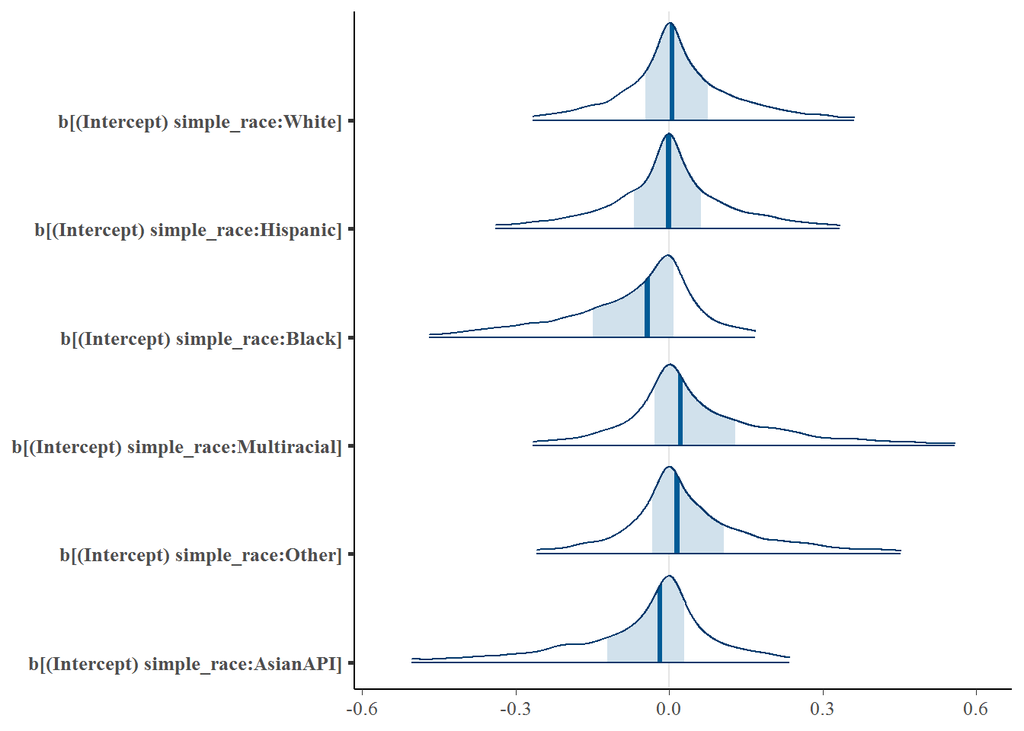

```r
# main race effects
plot(fit_comp, regex_pars = "b\\[\\(Intercept\\)\ simple_race\\:", prob_outer= 0.95, plotfun="areas")
```

```r
# calculate ORs and confidence intervals using the posterior draws
draws <- as.data.frame(fit_comp, pars=names(fixef(fit_comp)))
# OR for age
mean(exp(draws$`scale(Age_Entry_Years)`))
```

```
## [1] 1.33802
```

```r
# 95%CI
exp(quantile(draws$`scale(Age_Entry_Years)`, prob=c(0.025,0.975)))
```

```
##     2.5%    97.5%
## 1.147427 1.553158
```

```r
# OR for private insurance coverage
mean(exp(draws$ever_privateTRUE))
```

```
## [1] 1.833629
```

```r
# 95%CI
exp(quantile(draws$ever_privateTRUE, prob=c(0.025,0.975)))
```

```
##     2.5%    97.5%
## 1.369223 2.417438
```

```r
# OR for NEET
mean(exp(-draws$percent_NEET)) # flip sign to get OR for *not* being NEET
```

```
## [1] 2.571403
```

```r
# 95%CI
exp(quantile(-draws$percent_NEET, prob=c(0.025,0.975)))
```

```
##     2.5%    97.5%
## 1.417653 4.291708
```

```r
# OR for negative symptoms
mean(exp(draws$`scale(NEG_avg)`))
```

```
## [1] 0.6691529
```

```r
# 95%CI
exp(quantile(draws$`scale(NEG_avg)`, prob=c(0.025,0.975)))
```

```
##      2.5%     97.5%
## 0.5364538 0.8191770
```

Regarding program completion, there’s substantial variation by hub and by site.

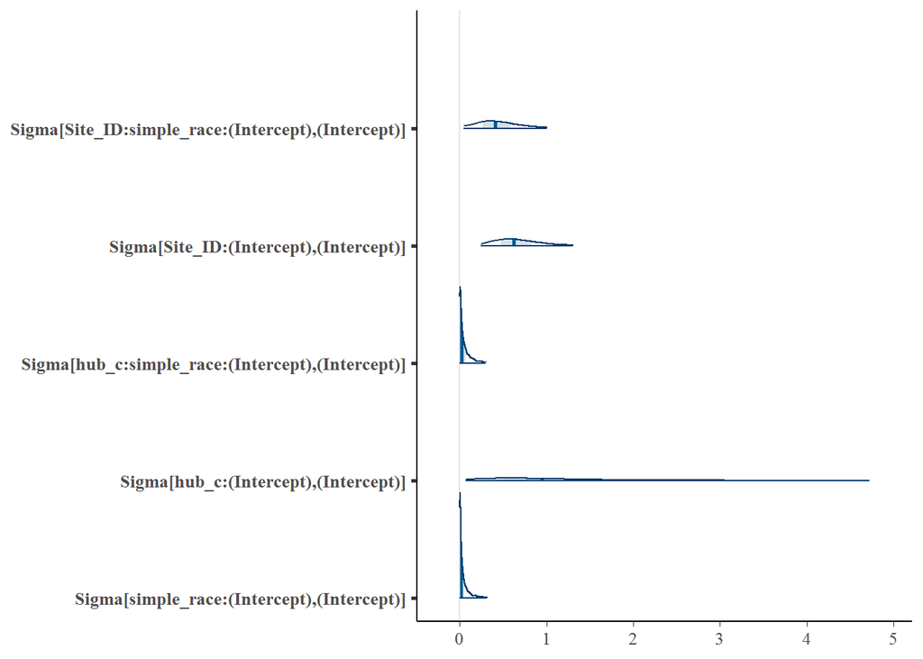

```r
plot(fit_comp, regex_pars = "Sigma", prob_outer=0.95, plotfun="areas")
```

```r
sigma_draws <- as.data.frame(fit_comp, regex_pars = "Sigma")
means <- data.frame(apply(sigma_draws, 2, mean))
CIs <- t(apply(sigma_draws, 2, function(x){quantile(x, probs=c(0.025,0.975))}))
sd_estimates <- cbind(means, CIs); names(sd_estimates)[1] <- "est"
sd_estimates
```

```
##                                                           est          2.5%
## Sigma[Site_ID:simple_race:(Intercept),(Intercept)] 0.44309673 0.04609038721
## Sigma[Site_ID:(Intercept),(Intercept)]             0.66381348 0.24420704599
## Sigma[hub_c:simple_race:(Intercept),(Intercept)]   0.05588683 0.00004686279
## Sigma[hub_c:(Intercept),(Intercept)]               1.30819933 0.06475704902
## Sigma[simple_race:(Intercept),(Intercept)]         0.05227878 0.00005072530
##                                                        97.5%
## Sigma[Site_ID:simple_race:(Intercept),(Intercept)] 1.0038078
## Sigma[Site_ID:(Intercept),(Intercept)]             1.3017215
## Sigma[hub_c:simple_race:(Intercept),(Intercept)]   0.2952444
## Sigma[hub_c:(Intercept),(Intercept)]               4.7157268
## Sigma[simple_race:(Intercept),(Intercept)]         0.3123491
```

Here are the hub effects (on the logit scale). Note LEAP is not included because they have fully missing age data and so the 53 LEAP discharges drop out of the regression. Completion rates for LEAP can still be estimated by the model using the observed hub-level distribution.

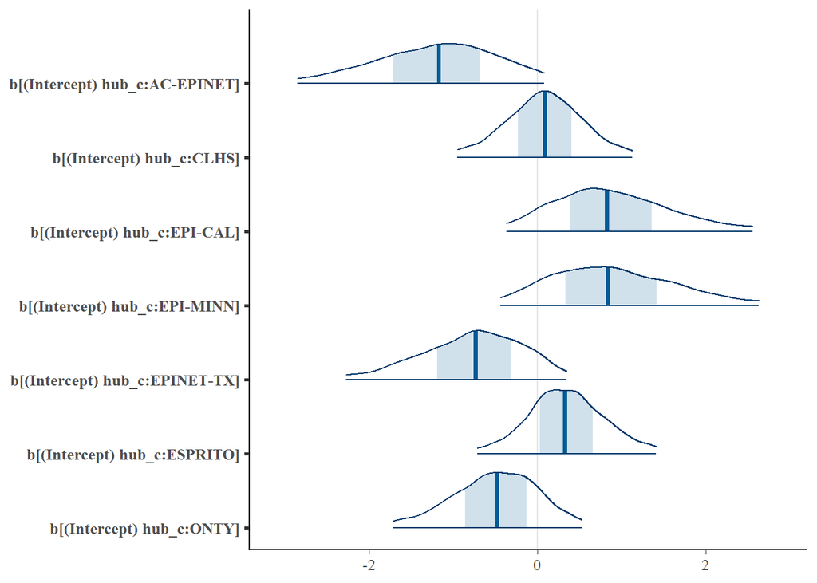

```r
plot(fit_comp, regex_pars = "t\\) hub_c:(O|A|E|C)", prob_outer=0.95, plotfun="areas")
```

```r
draws_hub <- as.data.frame(fit_comp, regex_pars = "t\\) hub_c:(O|A|E|L|C)")
difference <- draws_hub$`b[(Intercept) hub_c:ESPRITO]` - draws_hub$`b[(Intercept) hub_c:EPINET-TX]`
mean(exp(difference))
```

```
## [1] 3.850913
```

```r
quantile(exp(difference), prob=c(0.025,0.975))
```

```
##      2.5%     97.5%
##  0.995311 11.520883
```

There is less variability by race, and none of the differences between race are statistically significant.

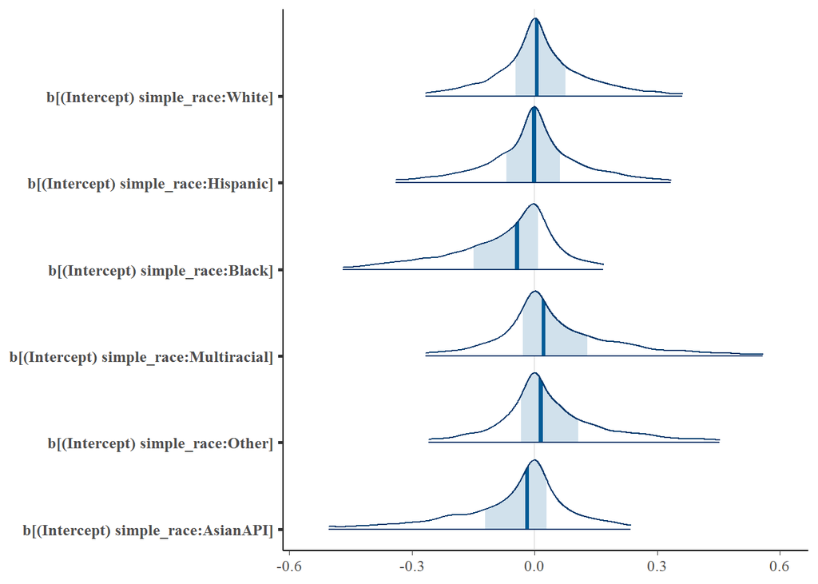

```r
plot(fit_comp, regex_pars = "t\\) simple_race", prob_outer=0.95, plotfun="areas")
```

```r
draws_race <- as.data.frame(fit_comp, regex_pars = "t\\) simple_race")
biggest_difference <- draws_race$`b[(Intercept) simple_race:Multiracial]` - draws_race$`b[(Intercept) simple_race:Black]`
mean(exp(biggest_difference))
```

```
## [1] 1.189367
```

```r
quantile(exp(biggest_difference), prob=c(0.025,0.975))
```

```
##      2.5%     97.5%
## 0.8019533 2.1170134
```

## 4.2 Lost contact

```r
fit_lost <-
  stan_glmer(
    lost_contact ~
      scale(Age_Entry_Years) +
      percent_NEET +
      male_c +
      ever_private +
      scale(QPR_avg) +
      scale(NEG_avg) +
      (1|simple_race) +
      (1|Site_ID)  +
      (1|hub_c) +
      # varying intercept for race
      # check if different hubs have different racial trajectories?
      (1  |Site_ID:simple_race) +
      (1 |hub_c:simple_race),
    data = dc_vis,
    adapt_delta=0.99,
    cores=4,
    family=binomial
  )
```

Interrogate the model.

```r
# overall output
print(fit_lost, digits=3)
```

```
## stan_glmer
##  family:       binomial [logit]
##  formula:      lost_contact ~ scale(Age_Entry_Years) + percent_NEET + male_c +
##     ever_private + scale(QPR_avg) + scale(NEG_avg) + (1 | simple_race) +
##     (1 | Site_ID) + (1 | hub_c) + (1 | Site_ID:simple_race) +
##     (1 | hub_c:simple_race)
##  observations: 1609
## ------
##                        Median MAD_SD
## (Intercept)            -2.255  0.424
## scale(Age_Entry_Years) -0.018  0.082
## percent_NEET            0.027  0.294
## male_cTRUE              0.413  0.166
## ever_privateTRUE       -0.450  0.162
## scale(QPR_avg)          0.227  0.161
## scale(NEG_avg)          0.085  0.099
##
## Error terms:
##  Groups              Name        Std.Dev.
##  Site_ID:simple_race (Intercept) 0.4780
##  Site_ID             (Intercept) 0.5350
##  hub_c:simple_race   (Intercept) 0.2986
##  hub_c               (Intercept) 0.6265
##  simple_race         (Intercept) 0.6768
## Num. levels: Site_ID:simple_race 310, Site_ID 86, hub_c:simple_race 41, hub_c 7, simple_race 6
##
## ------
## * For help interpreting the printed output see ?print.stanreg
## * For info on the priors used see ?prior_summary.stanreg
```

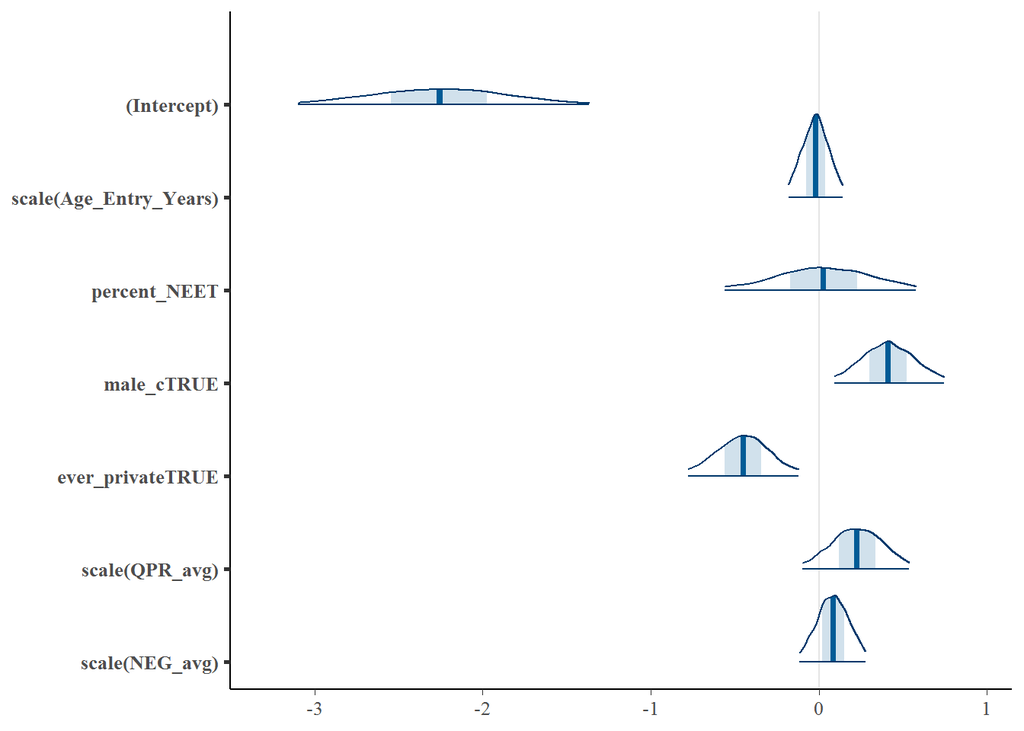

```r
# fixed effects
plot(fit_lost, pars = names(fixef(fit_lost)), prob_outer=0.95, plotfun="areas")
```

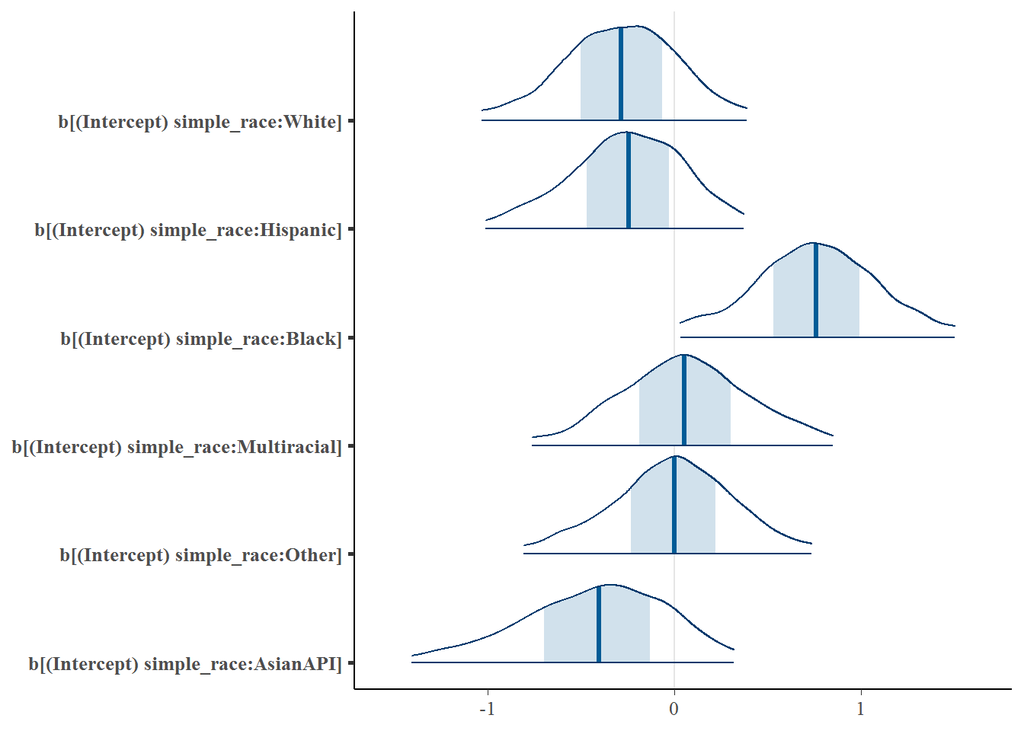

```r
# race effects (are substantial for this outcome)
plot(fit_lost, regex_pars = "b\\[\\(Intercept\\)\ simple_race\\:", prob_outer= 0.95, plotfun="areas")
```

```r
# calculate ORs and confidence intervals using posterior draws
draws <- as.data.frame(fit_lost, pars=names(fixef(fit_lost)))
# effect of being male
mean(exp(draws$male_cTRUE))
```

```
## [1] 1.533791
```

```r
# 95% CI
exp(quantile(draws$male_cTRUE, prob=c(0.025,0.975)))
```

```
##     2.5%    97.5%
## 1.098561 2.102246
```

```r
# effect of private insurance
mean(exp(draws$ever_privateTRUE))
```

```
## [1] 0.645468
```

```r
# 95% CI
exp(quantile(draws$ever_privateTRUE, prob=c(0.025,0.975)))
```

```
##      2.5%     97.5%
## 0.4593164 0.8844855
```

```r
# race effects
draws_race <- as.data.frame(fit_lost, regex_pars = "b\\[\\(Intercept\\)\ simple_race\\:")
# black people substantially more likely to have lost contact than white people
black_white_diff <- with(draws_race, `b[(Intercept) simple_race:Black]` - `b[(Intercept) simple_race:White]`)
#OR
mean(exp(black_white_diff))
```

```
## [1] 3.021695
```

```r
#95%CI
quantile(exp(black_white_diff), prob = c(0.025, 0.975))
```

```
##     2.5%    97.5%
## 1.206379 5.152579
```

```r
# difference between black and asian also significant
black_asian_diff <- with(draws_race, `b[(Intercept) simple_race:Black]` - `b[(Intercept) simple_race:AsianAPI]`)
#OR
mean(exp(black_asian_diff))
```

```
## [1] 3.725463
```

```r
#95%CI
quantile(exp(black_asian_diff), prob = c(0.025, 0.975))
```

```
##     2.5%    97.5%
## 1.201704 8.494808
```

```r
# difference between black and hispanic also significant
black_hisp_diff <- with(draws_race, `b[(Intercept) simple_race:Black]` - `b[(Intercept) simple_race:Hispanic]`)
#OR
mean(exp(black_hisp_diff))
```

```
## [1] 2.960781
```

```r
#95%CI
quantile(exp(black_hisp_diff), prob = c(0.025, 0.975))
```

```
##     2.5%    97.5%
## 1.192902 5.408228
```

```r
# difference between black and multiracial
black_multi_diff <- with(draws_race, `b[(Intercept) simple_race:Black]` - `b[(Intercept) simple_race:Multiracial]`)
#OR
mean(exp(black_multi_diff))
```

```
## [1] 2.196098
```

```r
#95%CI
quantile(exp(black_multi_diff), prob = c(0.025, 0.975))
```

```
##      2.5%     97.5%
## 0.9087752 4.5260508
```

```r
# difference between black and other
black_other_diff <- with(draws_race, `b[(Intercept) simple_race:Black]` - `b[(Intercept) simple_race:Other]`)
#OR
mean(exp(black_other_diff))
```

```
## [1] 2.324933
```

```r
#95%CI
quantile(exp(black_other_diff), prob = c(0.025, 0.975))
```

```
##      2.5%     97.5%
## 0.9853573 4.5254354
```

There’s less program- and hub-level variability for lost contact than for program completion, but it’s there. The most substantial variability we see in these random effects is the estimated standard deviation for race. There also appears to be variability in the relationship between race and lost contact across sites.

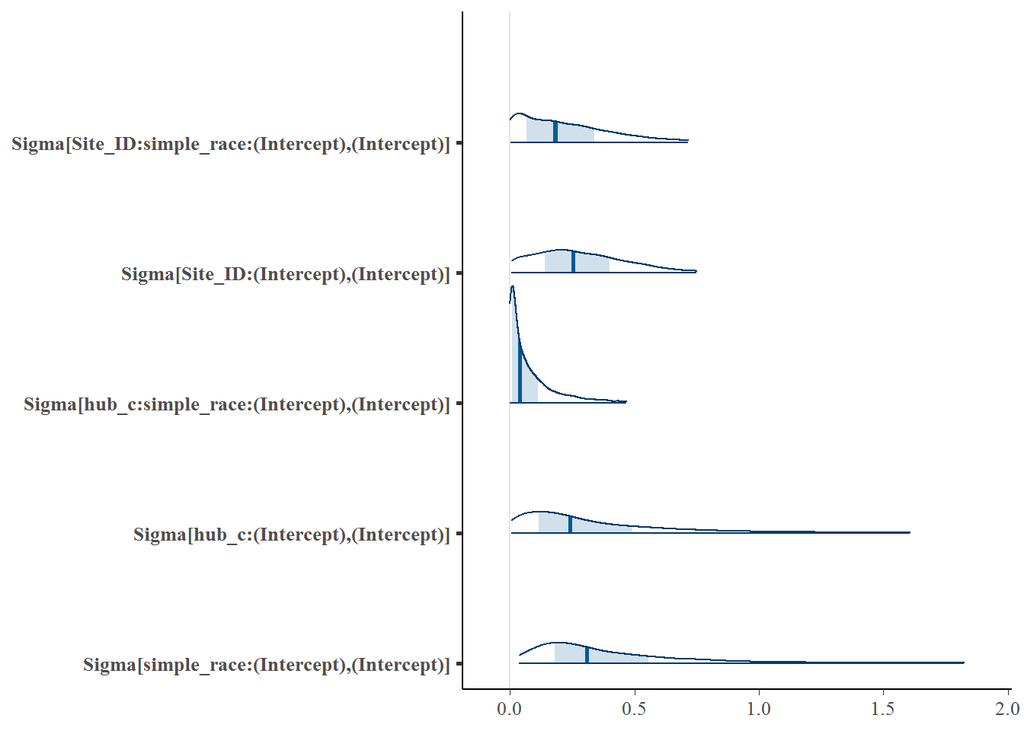

```r
plot(fit_lost, regex_pars = "Sigma", prob_outer=0.95, plotfun="areas")
```

```r
sigma_draws <- as.data.frame(fit_lost, regex_pars = "Sigma")
means <- data.frame(apply(sigma_draws, 2, mean))
CIs <- t(apply(sigma_draws, 2, function(x){quantile(x, probs=c(0.025,0.975))}))
sd_estimates <- cbind(means, CIs); names(sd_estimates)[1] <- "est"
sd_estimates
```

```
##                                                          est         2.5%
## Sigma[Site_ID:simple_race:(Intercept),(Intercept)] 0.2284999 0.0007348562
## Sigma[Site_ID:(Intercept),(Intercept)]             0.2862249 0.0055102774
## Sigma[hub_c:simple_race:(Intercept),(Intercept)]   0.0891474 0.0001323044
## Sigma[hub_c:(Intercept),(Intercept)]               0.3924918 0.0037405062
## Sigma[simple_race:(Intercept),(Intercept)]         0.4579949 0.0360529004
##                                                        97.5%
## Sigma[Site_ID:simple_race:(Intercept),(Intercept)] 0.7163858
## Sigma[Site_ID:(Intercept),(Intercept)]             0.7498976
## Sigma[hub_c:simple_race:(Intercept),(Intercept)]   0.4685355
## Sigma[hub_c:(Intercept),(Intercept)]               1.6066162
## Sigma[simple_race:(Intercept),(Intercept)]         1.8238435
```

Here are the hub effects.

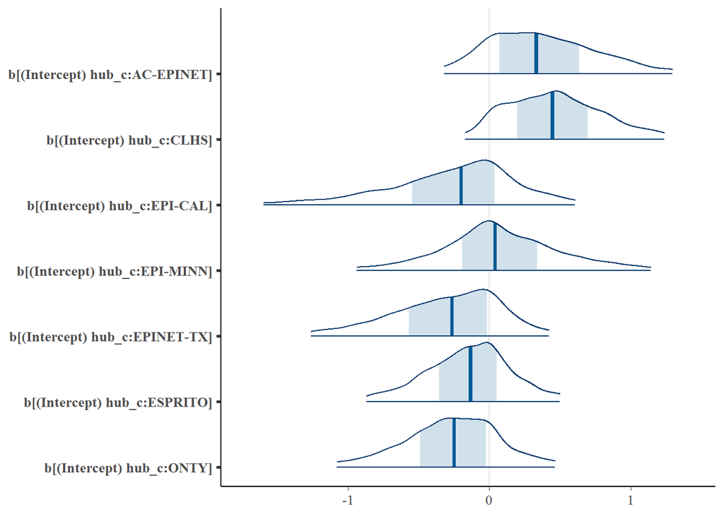

```r
plot(fit_lost, regex_pars = "t\\) hub_c:(O|A|E|C|L)", prob_outer=0.95, plotfun="areas")
```

## 4.3 Unilateral termination

```r
fit_uni <-
  stan_glmer(
    unilateral_termination ~
      scale(Age_Entry_Years) +
      percent_NEET +
      male_c +
      ever_private +
      scale(QPR_avg) +
      scale(NEG_avg) +
      (1|simple_race) +
      (1|Site_ID)  +
      (1|hub_c) +
      # varying intercept for race
      # check if different hubs have different racial trajectories?
      (1  |Site_ID:simple_race) +
      (1 |hub_c:simple_race),
    data = dc_vis,
    cores=4,
    family=binomial
  )
```

Interrogate the model.

```r
# full model
print(fit_uni, digits=3)
```

```
## stan_glmer
##  family:       binomial [logit]
##  formula:      unilateral_termination ~ scale(Age_Entry_Years) + percent_NEET +
##     male_c + ever_private + scale(QPR_avg) + scale(NEG_avg) +
##     (1 | simple_race) + (1 | Site_ID) + (1 | hub_c) + (1 | Site_ID:simple_race) +
##     (1 | hub_c:simple_race)
##  observations: 1609
## ------
##                        Median MAD_SD
## (Intercept)            -1.225  0.283
## scale(Age_Entry_Years) -0.117  0.071
## percent_NEET            0.028  0.229
## male_cTRUE              0.067  0.132
## ever_privateTRUE       -0.143  0.132
## scale(QPR_avg)          0.090  0.129
## scale(NEG_avg)          0.088  0.085
##
## Error terms:
##  Groups              Name        Std.Dev.
##  Site_ID:simple_race (Intercept) 0.1968
##  Site_ID             (Intercept) 0.5384
##  hub_c:simple_race   (Intercept) 0.3121
##  hub_c               (Intercept) 0.5354
##  simple_race         (Intercept) 0.2685
## Num. levels: Site_ID:simple_race 310, Site_ID 86, hub_c:simple_race 41, hub_c 7, simple_race 6
##
## ------
## * For help interpreting the printed output see ?print.stanreg
## * For info on the priors used see ?prior_summary.stanreg
```

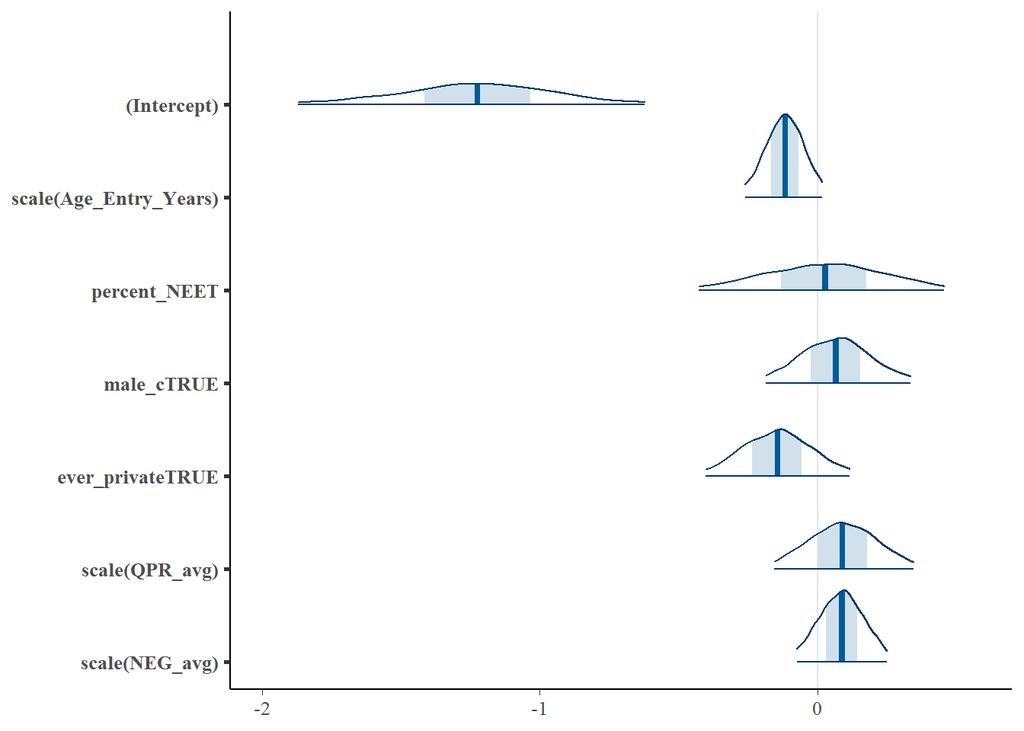

```r
# plot of fixed effects
plot(fit_uni, pars = names(fixef(fit_uni)), prob_outer=0.95, plotfun="areas")
```

```r
# age comes close to (but is not) statistically significant
posterior_interval(fit_uni, pars="scale(Age_Entry_Years)", prob=0.95)
```

```
##                              2.5%      97.5%
## scale(Age_Entry_Years) -0.2603549 0.01726058
```

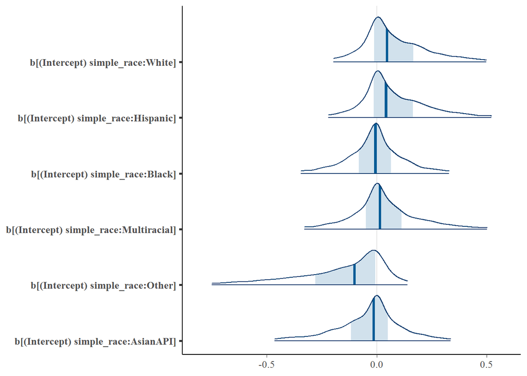

```r
# no real race effects
plot(fit_uni, regex_pars = "b\\[\\(Intercept\\)\ simple_race\\:", prob_outer= 0.95, plotfun="areas")
```

There was a fair amount of variability in unilateral termination by program. Less so by hub.

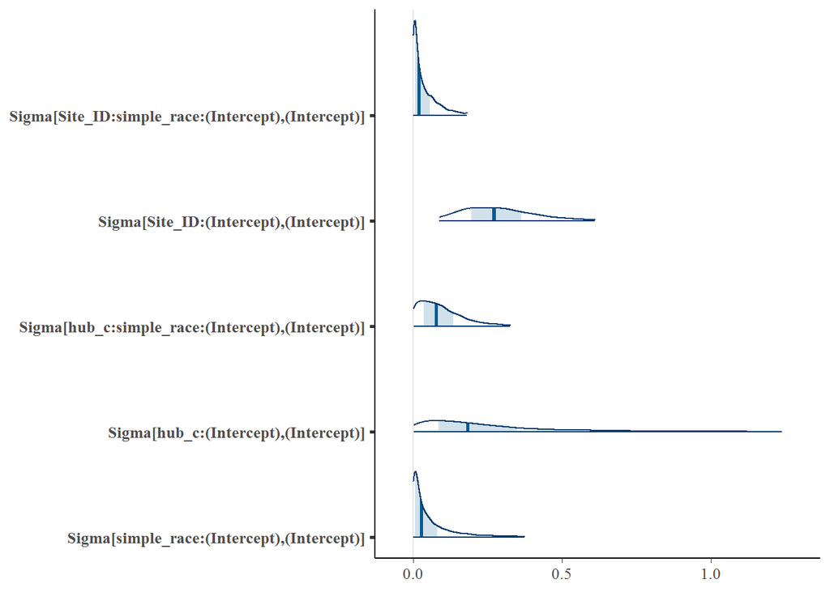

```r
plot(fit_uni, regex_pars = "Sigma", prob_outer=0.95, plotfun = "areas")
```

```r
sigma_draws <- as.data.frame(fit_uni, regex_pars = "Sigma")
means <- data.frame(apply(sigma_draws, 2, mean))
CIs <- t(apply(sigma_draws, 2, function(x){quantile(x, probs=c(0.025,0.975))}))
sd_estimates <- cbind(means, CIs); names(sd_estimates)[1] <- "est"
sd_estimates
```

```
##                                                           est          2.5%
## Sigma[Site_ID:simple_race:(Intercept),(Intercept)] 0.03873115 0.00003343512
## Sigma[Site_ID:(Intercept),(Intercept)]             0.28992637 0.08599491075
## Sigma[hub_c:simple_race:(Intercept),(Intercept)]   0.09742719 0.00071400301
## Sigma[hub_c:(Intercept),(Intercept)]               0.28669581 0.00180987923
## Sigma[simple_race:(Intercept),(Intercept)]         0.07210927 0.00010043213
##                                                        97.5%
## Sigma[Site_ID:simple_race:(Intercept),(Intercept)] 0.1799816
## Sigma[Site_ID:(Intercept),(Intercept)]             0.6087732
## Sigma[hub_c:simple_race:(Intercept),(Intercept)]   0.3248533
## Sigma[hub_c:(Intercept),(Intercept)]               1.2361803
## Sigma[simple_race:(Intercept),(Intercept)]         0.3734211
```

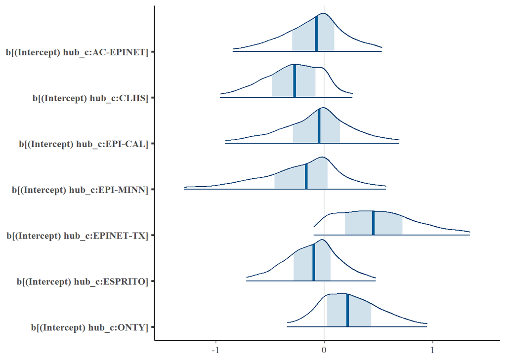

```r
plot(fit_uni, regex_pars = "t\\) hub_c:(O|A|E|C)", prob_outer=0.95, plotfun="areas")
```

```r
draws_hub <- as.data.frame(fit_uni, regex_pars = "t\\) hub_c:(O|A|E|L|C)")
difference <- draws_hub$`b[(Intercept) hub_c:EPINET-TX]` - draws_hub$`b[(Intercept) hub_c:CLHS]`
mean(exp(difference))
```

```
## [1] 2.438288
```

```r
quantile(exp(difference), probs=c(0.025, 0.975))
```

```
##      2.5%     97.5%
## 0.9882964 5.4119606
```

#### Transferred/moved?

At the request of a reviewer we also include a model for the “transferred or moved” category, although we do not report on this model in the main paper as we find the category both difficult to interpret and in many cases (e.g., moving to a different state) likely unrelated to treatment.

```r
fit_transfer <-
  stan_glmer(
    transferred_or_moved ~
      scale(Age_Entry_Years) +
      percent_NEET +
      male_c +
      ever_private +
      scale(QPR_avg) +
      scale(NEG_avg) +
      (1|simple_race) +
      (1|Site_ID)  +
      (1|hub_c) +
      # varying intercept for race
      # check if different hubs have different racial trajectories?
      (1  |Site_ID:simple_race) +
      (1 |hub_c:simple_race),
    data = dc_vis,
    cores=4,
    family=binomial
  )
```

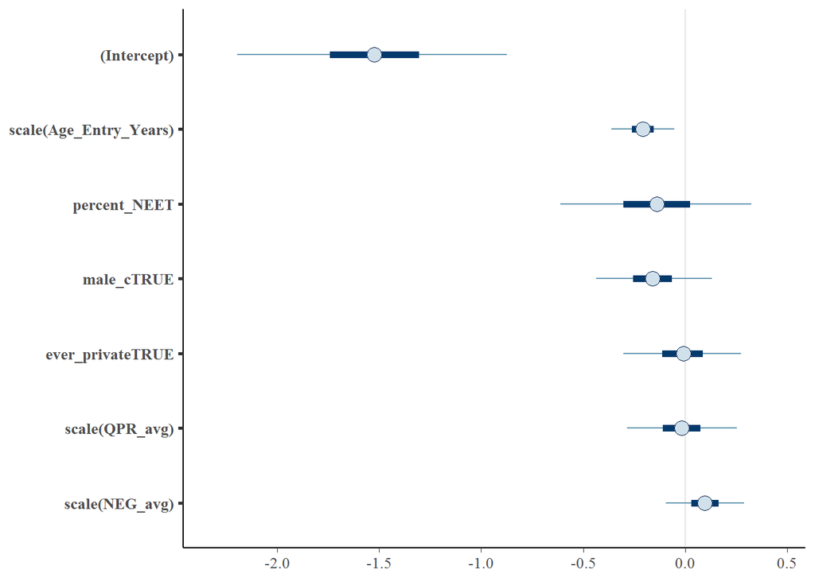

```r
plot(fit_transfer, pars = names(fixef(fit_transfer)), prob_outer=0.95)
```

## 4.4 Plot model results together

We build a plot of all the coefficients of the three primary models.

Start by combining draws for the fixed effects.

```r
draws_uni <- as.data.frame(fit_uni, pars = names(fixef(fit_uni)))
draws_lost <- as.data.frame(fit_lost, pars = names(fixef(fit_lost)))
draws_comp <- as.data.frame(fit_comp, pars = names(fixef(fit_comp)))
# race effects
race_draws_uni <- as.data.frame(fit_uni, regex_pars = "b\\[\\(Intercept\\)\ simple_race\\:")
race_draws_lost <- as.data.frame(fit_lost, regex_pars = "b\\[\\(Intercept\\)\ simple_race\\:")
race_draws_comp <- as.data.frame(fit_comp, regex_pars = "b\\[\\(Intercept\\)\ simple_race\\:")
draws_uni <- cbind(draws_uni, race_draws_uni)
draws_lost <- cbind(draws_lost, race_draws_lost)
draws_comp <- cbind(draws_comp, race_draws_comp)
# drop intercept
draws_uni <- draws_uni[-1]; draws_lost <- draws_lost[-1]; draws_comp <- draws_comp[-1]

# add random effects for race
draws_combined <- rbind(
  data.frame(draws_uni, model = "Unilateral termination"),
  data.frame(draws_lost, model = "Lost contact"),
  data.frame(draws_comp, model = "Program completion")
)

# rename for readability
names(draws_combined) <- c("Age (standardized)", "Percent of visits NEET", "Male","Ever privately insured", "QPR (standardized)","Negative Sx (standardized)", "Race:White", "Race:Hispanic", "Race:Black", "Race:Multiracial", "Race:Other", "Race:Asian/Pacific Islander", "Model")
```

Then build the plot.

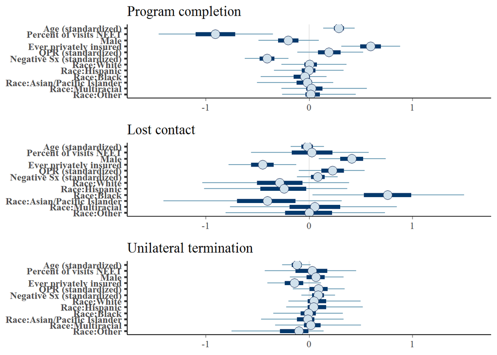

```r
par_labels <- c("Age (standardized)", "Percent of visits NEET", "Male", "Ever privately insured" , "QPR (standardized)","Negative Sx (standardized)","Race:White", "Race:Hispanic", "Race:Black", "Race:Asian/Pacific Islander","Race:Multiracial", "Race:Other")
bounds <- 1.6
coef_plot_uni <- bayesplot::mcmc_intervals(
  draws_combined %>% subset(Model == "Unilateral termination", select=-c(Model)),
  pars = par_labels,
  prob_outer = 0.95
) + xlim(-bounds,bounds) + ggtitle("Unilateral termination")
coef_plot_comp <- bayesplot::mcmc_intervals(
  draws_combined %>% subset(Model == "Program completion", select=-c(Model)),
    pars = par_labels,
  prob_outer = 0.95
) + xlim(-bounds,bounds) + ggtitle("Program completion")
coef_plot_lost <- bayesplot::mcmc_intervals(
  draws_combined %>% subset(Model == "Lost contact", select=-c(Model)),
    pars = par_labels,
  prob_outer = 0.95
) + xlim(-bounds,bounds) + ggtitle("Lost contact")
gridExtra::grid.arrange(coef_plot_comp, coef_plot_lost, coef_plot_uni, ncol=1)
```

# 5 Predictive modeling

We think our estimate of completion rate is an *under*estimate because the longer you stay in CSC the more likely you are to complete, and so all these people in the dataset who haven’t yet discharged become increasingly likely to complete the longer we track them.

We want a lower bound on our completion rate underestimate, so we fit a predictive model (basically the above model but with program duration added as a predictor, which is very, very strongly correlated with program completion).

```r
pred_comp <-
  stan_glmer(
    completed ~
      CSC_Duration_Totalmos + #### THIS IS THE ONLY NEW VARIABLE
      scale(Age_Entry_Years) +
      percent_NEET +
      male_c +
      ever_private +
      scale(QPR_avg) +
      scale(NEG_avg) +
      (1|simple_race) +
      (1|Site_ID)  +
      (1|hub_c) +
      (1|Site_ID:simple_race) +
      (1|hub_c:simple_race),
    data = dc_vis,
    cores=4,
    adapt_delta = 0.99,
    family=binomial
    )
```

We use this model to get predictions for the people who haven’t discharged yet.

```r
non_missing_cases <-
  dc_vis %>% select(CSC_Duration_Totalmos,
                  Age_Entry_Years,
                  percent_NEET,
                  simple_race,
                  male_c,
                  ever_private,
                  Site_ID,
                  QPR_avg,
                  hub_c,
                  completed
                  ) %>%
  complete.cases()
non_missing_discharged <- dc_vis[non_missing_cases,]
```

Let’s see how good the model is for in-sample predictions

```r
ppred <- posterior_epred(pred_comp, newdata = non_missing_discharged)
pred <- colMeans(ppred)
# model-predicted completion rate
mean(pred)
```

```
## [1] 0.2314023
```

```r
# actual completion rate
mean(non_missing_discharged$completed)
```

```
## [1] 0.2374145
```

Let’s plot model predicted program completion versus actuzal completion.

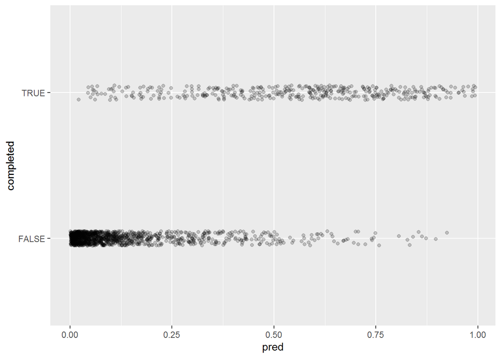

```r
non_missing_discharged$pred <- pred
non_missing_discharged %>%
  ggplot() +
  aes(x = pred, y = completed) +
  geom_jitter(width=0, height=0.05, alpha=0.2)
```

```r
confusionMatrix(factor(non_missing_discharged$pred >= 0.5, levels=c(FALSE, TRUE), labels=c("not completed", "completed")), # pred
                factor(non_missing_discharged$completed, levels=c(FALSE, TRUE), labels=c("not completed", "completed")) # truth
)
```

```
## Confusion Matrix and Statistics
##
##                Reference
## Prediction      not completed completed
##   not completed          1172       149
##   completed                55       233
##
##                Accuracy : 0.8732
##                  95% CI : (0.856, 0.8891)
##     No Information Rate : 0.7626
##     P-Value [Acc > NIR] : < 0.00000000000000022
##
##                   Kappa : 0.6174
##
##  Mcnemar's Test P-Value : 0.0000000000745
##
##             Sensitivity : 0.9552
##             Specificity : 0.6099
##          Pos Pred Value : 0.8872
##          Neg Pred Value : 0.8090
##              Prevalence : 0.7626
##          Detection Rate : 0.7284
##    Detection Prevalence : 0.8210
##       Balanced Accuracy : 0.7826
##
##        'Positive' Class : not completed
##
```

We use the above model to predict for the people who haven’t discharged yet

```r
latest <- dat %>%
  group_by(NDA_ID) %>%
  slice(which.max(Assessment_Type)) %>%
  subset(!(Assessment_Type %in% c(26,27))) %>%
  ungroup()

non_missing_latest <-
  latest %>% select(CSC_Duration_Totalmos,
                  Age_Entry_Years,
                  percent_NEET,
                  simple_race,
                  male_c,
                  ever_private,
                  QPR_avg,
                  NEG_avg,
                  Site_ID,
                  hub_c
                    ) %>%
  complete.cases()
non_missing_undischarged <- latest[non_missing_latest,]
ppred <- posterior_epred(pred_comp, newdata = non_missing_undischarged)
pred <- colMeans(ppred)
```

Model-predicted completion rates for people who haven’t discharged yet are actually *lower* than in the group that’s already discharged.

```r
mean(pred)
```

```
## [1] 0.1812476
```

This may partially be due to the fact that people who haven’t yet discharged are more likely to be earlier in the course of the program, and if they continue (which they will) their predicted and actual completion rates would both rise.

```r
mean(non_missing_undischarged$CSC_Duration_Totalmos)
```

```
## [1] 13.68466
```

```r
mean(non_missing_discharged$CSC_Duration_Totalmos)
```

```
## [1] 16.04351
```

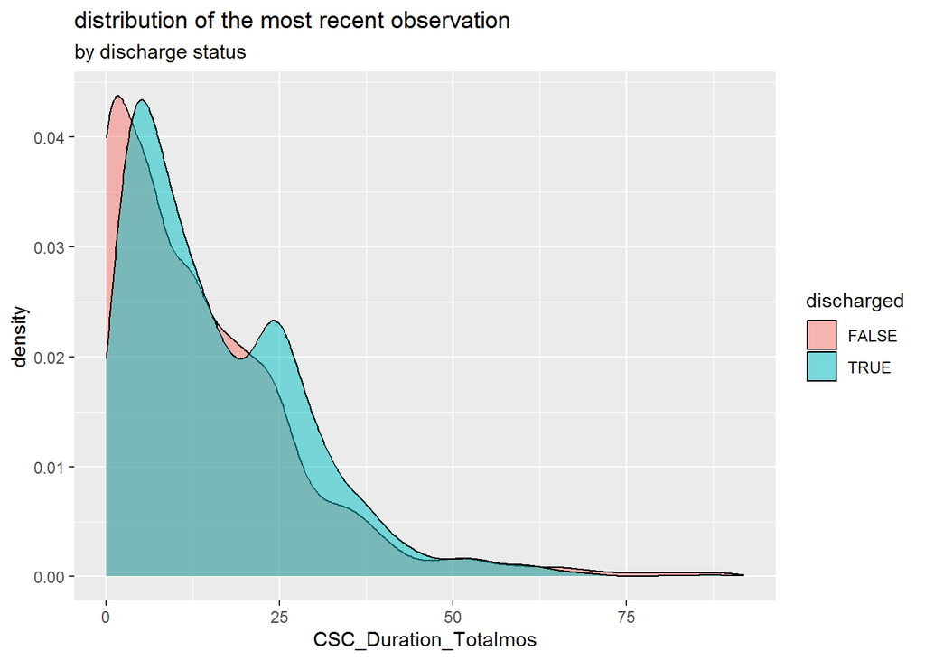

```r
non_missing_undischarged$discharged <- FALSE
non_missing_discharged$discharged <- TRUE
bind_rows(non_missing_undischarged, non_missing_discharged) %>%
  ggplot() +
  aes(x = CSC_Duration_Totalmos, fill = discharged) +
  geom_density(alpha=0.5) +
  ggtitle("distribution of the most recent observation",
          subtitle="by discharge status")
```

In any case, here is the predicted total hub-wide completion rate under various assumptions.

Assumption 1: that the latest observed enrollment duration is the final enrollment duration.

```r
ppred <- posterior_epred(pred_comp,
                         newdata =
                           bind_rows(non_missing_undischarged,
                                     non_missing_discharged) %>%
                           select(CSC_Duration_Totalmos,
                  Age_Entry_Years,
                  percent_NEET,
                  simple_race,
                  male_c,
                  ever_private,
                  QPR_avg,
                  NEG_avg,
                  Site_ID,
                  hub_c
                ))
pred <- colMeans(ppred)
mean(pred)
```

```
## [1] 0.2022029
```

…that the non-discharged folks will discharge at (at least) the mean of the discharged folks

```r
av_disch <- mean(non_missing_discharged$CSC_Duration_Totalmos)
non_missing_undischarged$CSC_Duration_Totalmos <-
  ifelse(non_missing_undischarged$CSC_Duration_Totalmos < av_disch, av_disch,non_missing_undischarged$CSC_Duration_Totalmos )
ppred <- posterior_epred(pred_comp,
                         newdata =
                           bind_rows(non_missing_undischarged,
                                     non_missing_discharged) %>%
                           select(CSC_Duration_Totalmos,
                  Age_Entry_Years,
                  percent_NEET,
                  simple_race,
                  male_c,
                  ever_private,
                  QPR_avg,
                  NEG_avg,
                  Site_ID,
                  hub_c
                  ))
pred <- colMeans(ppred)
mean(pred)
```

```
## [1] 0.2384769
```

…that the non-discharged folks will discharge at (at least) the upper quartile of the discharged folks

```r
(upper_quartile <- quantile(non_missing_discharged$CSC_Duration_Totalmos, 0.75))
```

```
## 75%
##  24
```

```r
non_missing_undischarged$CSC_Duration_Totalmos <-
  ifelse(non_missing_undischarged$CSC_Duration_Totalmos < upper_quartile, upper_quartile,non_missing_undischarged$CSC_Duration_Totalmos )

ppred <- posterior_epred(pred_comp,
                         newdata =
                           bind_rows(non_missing_undischarged,
                                     non_missing_discharged) %>%
                           select(CSC_Duration_Totalmos,
                                  Age_Entry_Years,
                                  percent_NEET,
                                  simple_race,
                                  male_c,
                                  ever_private,
                                  QPR_avg,
                                  NEG_avg,
                                  Site_ID,
                                  hub_c
                                  ))
pred <- colMeans(ppred)
mean(pred)
```

```
## [1] 0.292774
```